```r
# Libraries
library(ggplot2)
library(phyloseq)
library(vegan)
library(MGnifyR)
options(repr.plot.width = 16,repr.plot.height=8)
```

# MGnifyR - using MGnify data in R

## EBI Metagenomics workshop 2021

# Introduction

## Aims of the talk

- Introduce current fuctionality
  - In processing *order*.
- Get feedback!
  - might this be useful to *you*
  - what would *you* want to see?

## Aims of the package

- Simplify access to the data for R users.
- Familiar R friendly `data.frames`.
- No dictating analysis workflow.
- Only data retrieval, *not* analysis...
- ..but making the analysis easier.

## Current status

- Functionaly useful
- Many issues - active development
  - R based *and* server side.
  - help us find them.

In particular, is it right to use phyloseq? What else would be generally useful?

- R friendly way to access the API
- JSONAPI can be daunting for non-programmers
- Limited ability to ~combine~ datasets together.

Important to keep it as simple as possible - not a fan of creating specific object types and methods.

Issues mix of R side and server side API.

# MGnifyR overview

- Set of wrapper functions.
  - Data search and data retrieval.
  - *Consistent* parameters and style(?)
  - Process arbitrary collections studies/samples/assemblies together
- **Uses `analyses` accessions to identify data.**
  - Helper functions for conversion.
- Hides API complexity
  - pagination, authentication, etc.
- Local caching
  - significant speedups.
- Help
  - `?function_name`
  - Walkthrough vignette
  - Tab completion is your friend.

# Installation

- Requirements:
  - `devtools`
  - `phyloseq` - https://joey711.github.io/phyloseq

`install_github("beadyallen/MGnifyR")`

```r
devtools::install_github("beadyallen/MGnifyR", upgrade = F, force = T)
```

# 0 - `mgnify_client` object

- Required by all `MGnifyR` functions
  - cache location
  - username/password authentication
  - debug options

```r
library(MGnifyR)
mgnify_client()
```

```
An object of class "mgnify_client"
Slot "url":
[1] "https://www.ebi.ac.uk/metagenomics/api/v1"

Slot "authtok":
[1] NA

Slot "cache_dir":
[1] NA

Slot "warnings":
[1] FALSE

Slot "use_memcache":
[1] FALSE

Slot "memcache":
list()

Slot "clear_cache":
[1] FALSE
```

### Using authentication

- `username`/`password` combination

```r
mgnify_client(username = "Webin-44662", password = mypassword, usecache = T)
```

```
Error in mgnify_client(username = "Webin-44662", password = mypassword, : object 'mypassword' not found
Traceback:

1. mgnify_client(username = "Webin-44662", password = mypassword,
 .     usecache = T)
```

### Using the local query cache

- API results saved on your local harddrive.
- *Raw* api results. -post de-pagination.
- **MUCH** faster after initial download.
- Persistent across sessions
- *Somewhat* threadsafe...
- Not for all cases.

```r
mgnify_client(usecache = T)
```

```
An object of class "mgnify_client"
Slot "url":
[1] "https://www.ebi.ac.uk/metagenomics/api/v1"

Slot "authtok":
[1] NA

Slot "cache_dir":
[1] "/home/ben/Jupyter Workbooks/.MGnifyR_cache"

Slot "warnings":
[1] FALSE

Slot "use_memcache":
[1] FALSE

Slot "memcache":
list()

Slot "clear_cache":
[1] FALSE
```

```r
(mg <- mgnify_client(usecache = T, cache_dir = '~/MyLocalMGnifyCache'))
```

```
An object of class "mgnify_client"
Slot "url":
[1] "https://www.ebi.ac.uk/metagenomics/api/v1"

Slot "authtok":
[1] NA

Slot "cache_dir":
[1] "~/MyLocalMGnifyCache"

Slot "warnings":
[1] FALSE

Slot "use_memcache":
[1] FALSE

Slot "memcache":
list()

Slot "clear_cache":
[1] FALSE
```

Actual cache usage controlable at the query level.

#### Cache example

```r
search_result <- mgnify_analyses_from_studies(mg, "MGYS00005605", usecache = F)
```

```r
search_result <- mgnify_analyses_from_studies(mg, "MGYS00005605", usecache = T)
```

## Common `MGnifyR` function parameters

- `client` : `mgnify_client` object
- `accession` : single or multiple accessions (character vector)
- `maxhits` : how many entries to return for an API query.
- `usecache`: Enable/disable local caching.
- `asDataFrame`: Convert results to a single `data.frame` or return an unprocessed list

## 1 - `mgnify_query` - finding MGnify projects and results

- General search functionality
- Flexible filtering

`mgnify_query(client, qtype, accession, asDataFrame, maxhits, usecache, ...)`

- `qtype`: "studies", "samples", etc. What to search for?
- `accession`: Single accession of interest.
- `...` Extra filtering parameters.
- Returns `data.frame` of results.
- Caching **OFF** by default

```r
mgnify_query(mg, qtype="samples", maxhits=10, usecache = T)
```

A data.frame: 50 × 60

| biosample <chr> | accession <chr> | analysis-completed <chr> | geo-loc-name <chr> | sample-desc <chr> | sample-name <chr> | sample-alias <chr> | host-tax-id <chr> | species <chr> | last-update <chr> | ⋯ | photosynthetically active radiation <chr> | potential density <chr> | project name <chr> | environment (feature) <chr> | elevation <chr> | ENA checklist <chr> | host scientific name <chr> | host genotype <chr> | host phenotype <chr> | host sex <chr> |
| --- | --- | --- | --- | --- | --- | --- | --- | --- | --- | --- | --- | --- | --- | --- | --- | --- | --- | --- | --- | --- |
| SAMN01795786 | SRS373032 | 2016-03-15 | missing | Generic sample from unclassified Bacteria (miscellaneous) | PRJNA218187.11681_ST_14_1 | PRJNA218187.11681_ST_14_1 | 9606 | Homo sapiens | 2021-10-22T18:11:19 | ⋯ | NA | NA | NA | NA | NA | NA | NA | NA | NA | NA |
| SAMN03392605 | SRS875056 | NA | NA | Water phase of 2 ppm; 30µm median dispersed oil in unfiltered seawater | 2013-0164 | 2013-0164 | NA | NA | 2021-10-22T18:02:20 | ⋯ | NA | NA | NA | NA | NA | NA | NA | NA | NA | NA |
| SAMN03392596 | SRS874730 | NA | NA | Water phase of 2 ppm; 10µm median dispersed oil in unfiltered seawater | 2013-0124 | 2013-0124 | NA | NA | 2021-10-22T17:48:04 | ⋯ | NA | NA | NA | NA | NA | NA | NA | NA | NA | NA |
| SAMN15699246 | SRS7452828 | NA | NA | This sample has been submitted by pda\|benjamin.marie1978@gmail.com on 2020-10-01; Microcystis aeruginosa PMC 728.11 | Microcystis aeruginosa PMC 728.11 genome | Microcystis aeruginosa PMC 728.11 genome | NA | NA | 2021-10-22T17:45:43 | ⋯ | NA | NA | NA | NA | NA | NA | NA | NA | NA | NA |
| SAMN09489426 | SRS3481351 | NA | NA | Bacterial DNA sequence reads from human saliva | Metagenome | Metagenome | 9606 | NA | 2021-10-22T17:36:31 | ⋯ | NA | NA | NA | NA | NA | NA | NA | NA | NA | NA |
| SAMN02628402 | SRS567311 | 2014-05-09 | Western Tropical North Atlantic Ocean | This sample has been submitted by pda\|brando02345 on 2014-03-13; aquatic metagenome | ACM18 | ACM18 | NA | NA | 2021-10-22T17:25:36 | ⋯ | 65.38 | 18.97 | NA | NA | NA | NA | NA | NA | NA | NA |
| SAMEA5989477 | ERS3792294 | NA | NA | REHAB | RH0001-DID-DW-100-AUT | RH0001-DID-DW-100-AUT | NA | NA | 2021-10-22T16:38:30 | ⋯ | NA | NA | REHAB | Sediment | 0.0 | ERC000021 | NA | NA | NA | NA |
| SAMN02393652 | SRS500400 | 2017-11-01 | Canada: Ontario | Metagenomic library of activated sludge from pulp and paper waste treatment plant (CX4) | CX4 | CX4 | NA | NA | 2021-10-22T00:34:22 | ⋯ | NA | NA | Libraries for functional screening | NA | NA | NA | NA | NA | NA | NA |
| SAMN02324088 | SRS493612 | 2017-11-01 | Canada | Metagenomic library from agricultural soil (12AC) | 12AC | 12AC | NA | NA | 2021-10-22T00:32:54 | ⋯ | NA | NA | Libraries for functional screening | NA | NA | NA | NA | NA | NA | NA |
| SAMN02393686 | SRS500499 | 2017-11-01 | Canada: Laurel Creek, Waterloo, ON | Metagenomic library from creek bank soil (CX10) | CX10 | CX10 | NA | NA | 2021-10-22T00:29:02 | ⋯ | NA | NA | Libraries for functional screening | NA | NA | NA | NA | NA | NA | NA |
| SAMN02393684 | SRS500404 | 2017-11-01 | Canada: Laurel Creek, Waterloo, ON | Metagenomic library from creek bank soil (CX9) | CX9 | CX9 | NA | NA | 2021-10-22T00:26:18 | ⋯ | NA | NA | Libraries for functional screening | NA | NA | NA | NA | NA | NA | NA |
| SAMN02141832 | SRS499793 | 2017-11-01 | Canada | Environmental/Metagenome sample for cosmid clones from environmental metagenomic libraries | cosmid clones from metagenomic libraries | cosmid clones from metagenomic libraries | NA | NA | 2021-10-22T00:12:54 | ⋯ | NA | NA | Canadian MetaMicrobiome Library | NA | NA | NA | NA | NA | NA | NA |
| SAMN02324235 | SRS500406 | 2017-11-01 | Canada: Ontario | Metagenomic library of activated sludge from pulp and paper waste treatment plant (CX3) | CX3 | CX3 | NA | NA | 2021-10-22T00:08:58 | ⋯ | NA | NA | Libraries for functional screening | NA | NA | NA | NA | NA | NA | NA |
| SAMN02324081 | SRS500405 | 2017-11-01 | Canada: Ontario | Metagenomic library from human feces (CLGM1) | CLGM1 | CLGM1 | 9606 | NA | 2021-10-22T00:05:28 | ⋯ | NA | NA | Libraries for functional screening | NA | NA | NA | Homo sapiens | NA | NA | NA |
| SAMN02393657 | SRS500401 | 2017-11-01 | Canada: Ontario | Metagenomic library of activated sludge from municipal wastewater treatment plant (CX6) | CX6 | CX6 | NA | NA | 2021-10-21T23:24:58 | ⋯ | NA | NA | Libraries for functional screening | NA | NA | NA | NA | NA | NA | NA |
| SAMN04168658 | SRS1117528 | 2017-11-01 | NA | Amoxicillin 7 day treatment, day 7 | 1057 | 1057 | 9606 | Homo sapiens | 2021-10-21T23:17:14 | ⋯ | NA | NA | NA | stool | NA | NA | Homo sapiens | not collected | not collected | female |
| SAMN04168690 | SRS1117603 | 2017-11-01 | NA | A mock microbial community DNA sample, composed of a mixture 20 microbial genomic DNAs that vary in genome size (1.6 to 6.2 Mb) and G+C content (32 to 69%) obtained from BEI Resources (HM-276D; even, … | Mock | Mock | 9606 | Homo sapiens | 2021-10-21T23:13:51 | ⋯ | NA | NA | NA | NA | NA | NA | NA | NA | NA | NA |
| SAMN04168659 | SRS1117537 | 2018-04-12 | NA | Amoxicillin 7 day treatment, week 8 | 1058 | 1058 | 9606 | Homo sapiens | 2021-10-21T22:57:56 | ⋯ | NA | NA | NA | stool | NA | NA | Homo sapiens | not collected | not collected | female |
| SAMN04168656 | SRS1117397 | 2017-11-01 | NA | Amoxicillin 7 day treatment, day 0 | 1055 | 1055 | 9606 | Homo sapiens | 2021-10-21T22:38:44 | ⋯ | NA | NA | NA | stool | NA | NA | Homo sapiens | not collected | not collected | female |
| SAMN04168657 | SRS1117522 | 2017-11-01 | NA | Amoxicillin 7 day treatment, day 3 | 1056 | 1056 | 9606 | Homo sapiens | 2021-10-21T22:28:15 | ⋯ | NA | NA | NA | stool | NA | NA | Homo sapiens | not collected | not collected | female |
| SAMN02628405 | SRS567886 | 2014-05-08 | Western Tropical North Atlantic Ocean | This sample has been submitted by pda\|brando02345 on 2014-03-14; aquatic metagenome | ACM20 | ACM20 | NA | NA | 2021-10-21T08:23:53 | ⋯ | 27.94 | 15.62 | NA | NA | NA | NA | NA | NA | NA | NA |
| SAMN02628422 | SRS580500 | 2014-05-09 | Western Tropical North Atlantic Ocean | This sample has been submitted by pda\|brando02345 on 2014-03-26; aquatic metagenome | ACM55 | ACM55 | NA | NA | 2021-10-21T08:16:06 | ⋯ | 80.36 | 23.04 | NA | NA | NA | NA | NA | NA | NA | NA |
| SAMN02628410 | SRS580495 | 2014-05-09 | Western Tropical North Atlantic Ocean | This sample has been submitted by pda\|brando02345 on 2014-03-26; aquatic metagenome | ACM25 | ACM25 | NA | NA | 2021-10-21T08:13:06 | ⋯ | 16.71 | 19.78 | NA | NA | NA | NA | NA | NA | NA | NA |
| SAMN02628404 | SRS565748 | 2014-05-09 | Western Tropical North Atlantic Ocean | This sample has been submitted by pda\|brando02345 on 2014-03-10; aquatic metagenome | ACM2 | ACM2 | NA | NA | 2021-10-21T08:03:50 | ⋯ | 16.71 | 19.78 | NA | NA | NA | NA | NA | NA | NA | NA |
| SAMN05944599 | SRS1776191 | NA | NA | This sample has been submitted by pda\|brando02345 on 2016-11-04; aquatic metagenome | ACJ48 | ACJ48 | NA | NA | 2021-10-21T07:52:28 | ⋯ | NA | NA | NA | Amazon River Plume | NA | NA | NA | NA | NA | NA |
| SAMN02628407 | SRS581965 | 2014-05-09 | Western Tropical North Atlantic Ocean | This sample has been submitted by pda\|brando02345 on 2014-03-27; aquatic metagenome | ACM22 | ACM22 | NA | NA | 2021-10-21T07:37:26 | ⋯ | 73.71 | 19.65 | NA | NA | NA | NA | NA | NA | NA | NA |
| SAMN03252808 | SRS837379 | NA | NA | This sample has been submitted by pda\|brando02345 on 2015-02-06; aquatic metagenome | RCM32 | RCM32 | NA | NA | 2021-10-21T07:14:45 | ⋯ | NA | NA | NA | Amazon River | NA | NA | NA | NA | NA | NA |
| SAMN05944594 | SRS1776201 | NA | NA | This sample has been submitted by pda\|brando02345 on 2016-11-04; aquatic metagenome | ACJ43 | ACJ43 | NA | NA | 2021-10-21T06:52:45 | ⋯ | NA | NA | NA | Amazon River Plume | NA | NA | NA | NA | NA | NA |
| SAMN05944603 | SRS1776180 | NA | NA | This sample has been submitted by pda\|brando02345 on 2016-11-04; aquatic metagenome | ACJ28 | ACJ28 | NA | NA | 2021-10-21T06:47:05 | ⋯ | NA | NA | NA | Amazon River Plume | NA | NA | NA | NA | NA | NA |
| SAMN05944591 | SRS1776198 | NA | NA | This sample has been submitted by pda\|brando02345 on 2016-11-04; aquatic metagenome | ACJ40 | ACJ40 | NA | NA | 2021-10-21T06:45:31 | ⋯ | NA | NA | NA | Amazon River Plume | NA | NA | NA | NA | NA | NA |
| SAMN05944737 | SRS1776416 | NA | NA | Metagenome | RCJ29 | RCJ29 | NA | NA | 2021-10-21T06:32:50 | ⋯ | NA | NA | NA | Amazon River water | NA | NA | NA | NA | NA | NA |
| SAMN05944720 | SRS1776517 | NA | NA | Metagenome | RCJ38 | RCJ38 | NA | NA | 2021-10-21T06:15:16 | ⋯ | NA | NA | NA | Amazon River water | NA | NA | NA | NA | NA | NA |
| SAMN03252824 | SRS842033 | NA | NA | This sample has been submitted by pda\|brando02345 on 2015-02-12; aquatic metagenome | RCM48 | RCM48 | NA | NA | 2021-10-21T05:42:39 | ⋯ | NA | NA | NA | Amazon River | NA | NA | NA | NA | NA | NA |
| SAMN03252812 | SRS837556 | NA | NA | This sample has been submitted by pda\|brando02345 on 2015-02-06; aquatic metagenome | RCM36 | RCM36 | NA | NA | 2021-10-21T05:37:47 | ⋯ | NA | NA | NA | Amazon River | NA | NA | NA | NA | NA | NA |
| SAMN05944592 | SRS1776199 | NA | NA | This sample has been submitted by pda\|brando02345 on 2016-11-04; aquatic metagenome | ACJ41 | ACJ41 | NA | NA | 2021-10-21T05:11:47 | ⋯ | NA | NA | NA | Amazon River Plume | NA | NA | NA | NA | NA | NA |
| SAMN03252814 | SRS837591 | NA | NA | This sample has been submitted by pda\|brando02345 on 2015-02-06; aquatic metagenome | RCM38 | RCM38 | NA | NA | 2021-10-21T04:46:10 | ⋯ | NA | NA | NA | Amazon River | NA | NA | NA | NA | NA | NA |
| SAMN03252802 | SRS836421 | NA | NA | This sample has been submitted by pda\|brando02345 on 2015-02-05; aquatic metagenome | RCM26 | RCM26 | NA | NA | 2021-10-21T04:14:25 | ⋯ | NA | NA | NA | Amazon River | NA | NA | NA | NA | NA | NA |
| SAMN05944724 | SRS1872835 | NA | NA | Metagenome | RCJ42 | RCJ42 | NA | NA | 2021-10-21T04:01:49 | ⋯ | NA | NA | NA | Amazon River water | NA | NA | NA | NA | NA | NA |
| SAMN02628421 | SRS584253 | 2014-05-09 | Western Tropical North Atlantic Ocean | This sample has been submitted by pda\|brando02345 on 2014-04-08; aquatic metagenome | ACM54 | ACM54 | NA | NA | 2021-10-21T03:58:45 | ⋯ | 73.71 | 19.65 | NA | NA | NA | NA | NA | NA | NA | NA |
| SAMN05944725 | SRS1872839 | NA | NA | Metagenome | RCJ43 | RCJ43 | NA | NA | 2021-10-21T03:41:23 | ⋯ | NA | NA | NA | Amazon River water | NA | NA | NA | NA | NA | NA |
| SAMN03252811 | SRS837532 | NA | NA | This sample has been submitted by pda\|brando02345 on 2015-02-06; aquatic metagenome | RCM35 | RCM35 | NA | NA | 2021-10-21T03:30:46 | ⋯ | NA | NA | NA | Amazon River | NA | NA | NA | NA | NA | NA |
| SAMN05944719 | SRS1776507 | NA | NA | Metagenome | RCJ37 | RCJ37 | NA | NA | 2021-10-21T03:17:45 | ⋯ | NA | NA | NA | Amazon River water | NA | NA | NA | NA | NA | NA |
| SAMN05944741 | SRS1776492 | NA | NA | Metagenome | RCJ35 | RCJ35 | NA | NA | 2021-10-21T03:09:48 | ⋯ | NA | NA | NA | Amazon River water | NA | NA | NA | NA | NA | NA |
| SAMEA3231344 | ERS652568 | NA | NA | Human stool sample | peacemaker-13-392-2 | peacemaker-13-392-2 | 9606 | Homo sapiens | 2021-10-20T08:44:06 | ⋯ | NA | NA | Assessing temporal and technical variability of human gut metagenomes | NA | NA | ERC000011 | Homo sapiens | NA | NA | male |
| SAMEA3231320 | ERS652544 | NA | NA | Human stool sample | bugkiller-11-0-0 | bugkiller-11-0-0 | 9606 | Homo sapiens | 2021-10-20T08:40:28 | ⋯ | NA | NA | Assessing temporal and technical variability of human gut metagenomes | NA | NA | ERC000011 | Homo sapiens | NA | NA | male |
| SAMEA3231313 | ERS652537 | NA | NA | Human stool sample | alien-13-392-2 | alien-13-392-2 | 9606 | Homo sapiens | 2021-10-20T08:38:24 | ⋯ | NA | NA | Assessing temporal and technical variability of human gut metagenomes | NA | NA | ERC000011 | Homo sapiens | NA | NA | male |
| SAMEA3231330 | ERS652554 | NA | NA | Human stool sample | bugkiller-13-392-2 | bugkiller-13-392-2 | 9606 | Homo sapiens | 2021-10-20T08:32:58 | ⋯ | NA | NA | Assessing temporal and technical variability of human gut metagenomes | NA | NA | ERC000011 | Homo sapiens | NA | NA | male |
| SAMEA3231341 | ERS652565 | NA | NA | Human stool sample | peacemaker-11-392-2 | peacemaker-11-392-2 | 9606 | Homo sapiens | 2021-10-20T08:30:31 | ⋯ | NA | NA | Assessing temporal and technical variability of human gut metagenomes | NA | NA | ERC000011 | Homo sapiens | NA | NA | male |
| SAMEA3231308 | ERS652532 | NA | NA | Human stool sample | alien-11-380-0 | alien-11-380-0 | 9606 | Homo sapiens | 2021-10-20T08:28:29 | ⋯ | NA | NA | Assessing temporal and technical variability of human gut metagenomes | NA | NA | ERC000011 | Homo sapiens | NA | NA | male |
| SAMEA3231322 | ERS652546 | NA | NA | Human stool sample | bugkiller-11-7-0 | bugkiller-11-7-0 | 9606 | Homo sapiens | 2021-10-20T08:27:34 | ⋯ | NA | NA | Assessing temporal and technical variability of human gut metagenomes | NA | NA | ERC000011 | Homo sapiens | NA | NA | male |

Columns are concatenated - lots of NAs

Notes about the "maxhits" parameter

- stops at pagination boundaries
- Get more results than expected.

  Discuss caching queries - generally not advised because new results added all the time.

```r
d <- mgnify_query(mg, qtype = "studies", maxhits=10, usecache = T)
colnames(d)
```

1. 'bioproject'

2. 'samples-count'

3. 'accession'

4. 'secondary-accession'

5. 'centre-name'

6. 'is-public'

7. 'study-abstract'

8. 'study-name'

9. 'data-origination'

10. 'last-update'

11. 'acc_type'

12. 'type'

### Using filters (...)

- Server side result filtering
  - See help (`?`)

Need to do this because retrieving ALL samples to then post-filter is too difficult. Interface could be better though.

- Studies:
  - accession, biome_name, lineage, centre_name
- Samples:
  - accession, experiment_type, biome_name lineage, geo_loc_name, latitude_gte, latitude_lte, longitude_gte, longitude_lte, species, instrument_model, instrument_platform, **metadata_key, metadata_value_gte, metadata_value_lte, metadata_value**, environment_material, environment_feature, study_accession
- Runs
  - accession, experiment_type, biome_name, lineage, species, instrument_platform, instrument_model

```r
mgnify_query(mg, qtype = "analyses", experiment_type="amplicon", usecache = T)
```

A data.frame: 225 × 24

| pipeline-version <chr> | analysis-summary.key <chr> | analysis-summary.value <chr> | analysis-summary.key.1 <chr> | analysis-summary.value.1 <chr> | analysis-summary.key.2 <chr> | analysis-summary.value.2 <chr> | analysis-summary.key.3 <chr> | analysis-summary.value.3 <chr> | analysis-summary.key.4 <chr> | ⋯ | analysis-status <chr> | experiment-type <chr> | complete-time <chr> | instrument-platform <chr> | instrument-model <chr> | acc_type <chr> | sample <chr> | study <chr> | run <chr> | type <chr> |
| --- | --- | --- | --- | --- | --- | --- | --- | --- | --- | --- | --- | --- | --- | --- | --- | --- | --- | --- | --- | --- |
| 5.0 | Submitted nucleotide sequences | 55799 | Nucleotide sequences after format-specific filtering | 55789 | Nucleotide sequences after length filtering | 55789 | Nucleotide sequences after undetermined bases filtering | 55789 | Predicted SSU sequences | ⋯ | completed | amplicon | 2020-06-11T10:51:27 | ILLUMINA | Illumina MiSeq | analysis-jobs | ERS2075820 | MGYS00002115 | ERR2237853 | analysis-jobs |
| 5.0 | Submitted nucleotide sequences | 905 | Nucleotide sequences after format-specific filtering | 889 | Nucleotide sequences after length filtering | 889 | Nucleotide sequences after undetermined bases filtering | 889 | Predicted SSU sequences | ⋯ | completed | amplicon | 2020-11-05T20:43:04 | ILLUMINA | Illumina MiSeq | analysis-jobs | SRS3051409 | MGYS00005251 | SRR6843879 | analysis-jobs |
| 5.0 | Submitted nucleotide sequences | 931 | Nucleotide sequences after format-specific filtering | 899 | Nucleotide sequences after length filtering | 899 | Nucleotide sequences after undetermined bases filtering | 899 | Predicted SSU sequences | ⋯ | completed | amplicon | 2020-11-05T20:43:23 | ILLUMINA | Illumina MiSeq | analysis-jobs | SRS3051412 | MGYS00005251 | SRR6843877 | analysis-jobs |
| 5.0 | Submitted nucleotide sequences | 965 | Nucleotide sequences after format-specific filtering | 939 | Nucleotide sequences after length filtering | 939 | Nucleotide sequences after undetermined bases filtering | 939 | Predicted SSU sequences | ⋯ | completed | amplicon | 2020-11-05T20:04:56 | ILLUMINA | Illumina MiSeq | analysis-jobs | SRS3051410 | MGYS00005251 | SRR6843876 | analysis-jobs |
| 5.0 | Submitted nucleotide sequences | 872 | Nucleotide sequences after format-specific filtering | 837 | Nucleotide sequences after length filtering | 837 | Nucleotide sequences after undetermined bases filtering | 837 | Predicted SSU sequences | ⋯ | completed | amplicon | 2020-11-05T21:30:23 | ILLUMINA | Illumina MiSeq | analysis-jobs | SRS3051414 | MGYS00005251 | SRR6843872 | analysis-jobs |
| 5.0 | Submitted nucleotide sequences | 173961 | Nucleotide sequences after format-specific filtering | 162050 | Nucleotide sequences after length filtering | 162050 | Nucleotide sequences after undetermined bases filtering | 162050 | Predicted SSU sequences | ⋯ | completed | amplicon | 2020-11-15T15:10:44 | ILLUMINA | Illumina HiSeq 2500 | analysis-jobs | SRS2217638 | MGYS00005169 | SRR5586556 | analysis-jobs |
| 5.0 | Submitted nucleotide sequences | 307808 | Nucleotide sequences after format-specific filtering | 285952 | Nucleotide sequences after length filtering | 285952 | Nucleotide sequences after undetermined bases filtering | 285952 | Predicted SSU sequences | ⋯ | completed | amplicon | 2020-11-15T09:20:08 | ILLUMINA | Illumina HiSeq 2500 | analysis-jobs | SRS2217644 | MGYS00005169 | SRR5586551 | analysis-jobs |
| 5.0 | Submitted nucleotide sequences | 74600 | Nucleotide sequences after format-specific filtering | 74581 | Nucleotide sequences after length filtering | 74581 | Nucleotide sequences after undetermined bases filtering | 74581 | Predicted SSU sequences | ⋯ | completed | amplicon | 2020-03-11T11:35:39 | ILLUMINA | Illumina MiSeq | analysis-jobs | ERS2075827 | MGYS00002115 | ERR2237860 | analysis-jobs |
| 5.0 | Submitted nucleotide sequences | 74114 | Nucleotide sequences after format-specific filtering | 74090 | Nucleotide sequences after length filtering | 74090 | Nucleotide sequences after undetermined bases filtering | 74090 | Predicted SSU sequences | ⋯ | completed | amplicon | 2020-03-11T11:42:55 | ILLUMINA | Illumina MiSeq | analysis-jobs | ERS2075825 | MGYS00002115 | ERR2237858 | analysis-jobs |
| 5.0 | Submitted nucleotide sequences | 8348 | Nucleotide sequences after format-specific filtering | 8347 | Nucleotide sequences after length filtering | 8347 | Nucleotide sequences after undetermined bases filtering | 8347 | Predicted SSU sequences | ⋯ | completed | amplicon | 2020-03-11T11:29:04 | ILLUMINA | Illumina MiSeq | analysis-jobs | ERS2075823 | MGYS00002115 | ERR2237856 | analysis-jobs |
| 5.0 | Submitted nucleotide sequences | 84803 | Nucleotide sequences after format-specific filtering | 84788 | Nucleotide sequences after length filtering | 84788 | Nucleotide sequences after undetermined bases filtering | 84788 | Predicted SSU sequences | ⋯ | completed | amplicon | 2020-03-11T11:21:45 | ILLUMINA | Illumina MiSeq | analysis-jobs | ERS2075821 | MGYS00002115 | ERR2237854 | analysis-jobs |
| 5.0 | Submitted nucleotide sequences | 35959 | Nucleotide sequences after format-specific filtering | 31201 | Nucleotide sequences after length filtering | 31201 | Nucleotide sequences after undetermined bases filtering | 31201 | Predicted SSU sequences | ⋯ | completed | amplicon | 2020-03-11T09:24:37 | LS454 | 454 GS FLX Titanium | analysis-jobs | ERS477999 | MGYS00000492 | ERR315852 | analysis-jobs |
| 5.0 | Submitted nucleotide sequences | 44989 | Nucleotide sequences after format-specific filtering | 32627 | Nucleotide sequences after length filtering | 32627 | Nucleotide sequences after undetermined bases filtering | 32627 | Predicted SSU sequences | ⋯ | completed | amplicon | 2020-03-11T14:41:28 | LS454 | 454 GS FLX Titanium | analysis-jobs | ERS478017 | MGYS00000492 | ERR315850 | analysis-jobs |
| 5.0 | Submitted nucleotide sequences | 15487 | Nucleotide sequences after format-specific filtering | 11828 | Nucleotide sequences after length filtering | 11828 | Nucleotide sequences after undetermined bases filtering | 11828 | Predicted SSU sequences | ⋯ | completed | amplicon | 2020-08-21T11:24:30 | LS454 | 454 GS FLX Titanium | analysis-jobs | ERS492648 | MGYS00001811 | ERR632202 | analysis-jobs |
| 5.0 | Submitted nucleotide sequences | 136377 | Nucleotide sequences after format-specific filtering | 135647 | Nucleotide sequences after length filtering | 135647 | Nucleotide sequences after undetermined bases filtering | 135647 | Predicted SSU sequences | ⋯ | completed | amplicon | 2020-08-21T11:25:02 | ILLUMINA | Illumina MiSeq | analysis-jobs | ERS492647 | MGYS00001811 | ERR632201 | analysis-jobs |
| 5.0 | Submitted nucleotide sequences | 65644 | Nucleotide sequences after format-specific filtering | 56368 | Nucleotide sequences after length filtering | 56368 | Nucleotide sequences after undetermined bases filtering | 56368 | Predicted SSU sequences | ⋯ | completed | amplicon | 2020-08-21T11:26:50 | LS454 | 454 GS FLX Titanium | analysis-jobs | ERS492647 | MGYS00001811 | ERR632197 | analysis-jobs |
| 5.0 | Submitted nucleotide sequences | 45530 | Nucleotide sequences after format-specific filtering | 34232 | Nucleotide sequences after length filtering | 34232 | Nucleotide sequences after undetermined bases filtering | 34232 | Predicted SSU sequences | ⋯ | completed | amplicon | 2020-08-21T11:28:13 | LS454 | 454 GS FLX Titanium | analysis-jobs | ERS490089 | MGYS00001811 | ERR632192 | analysis-jobs |
| 5.0 | Submitted nucleotide sequences | 198435 | Nucleotide sequences after format-specific filtering | 193419 | Nucleotide sequences after length filtering | 193419 | Nucleotide sequences after undetermined bases filtering | 193419 | Predicted SSU sequences | ⋯ | completed | amplicon | 2020-08-21T11:29:00 | ILLUMINA | Illumina MiSeq | analysis-jobs | ERS492648 | MGYS00001811 | ERR632189 | analysis-jobs |
| 5.0 | Submitted nucleotide sequences | 38256 | Nucleotide sequences after format-specific filtering | 30970 | Nucleotide sequences after length filtering | 30970 | Nucleotide sequences after undetermined bases filtering | 30970 | Predicted SSU sequences | ⋯ | completed | amplicon | 2020-08-21T11:32:51 | LS454 | 454 GS FLX Titanium | analysis-jobs | ERS492648 | MGYS00001811 | ERR632178 | analysis-jobs |
| 5.0 | Submitted nucleotide sequences | 132 | Nucleotide sequences after format-specific filtering | 130 | Nucleotide sequences after length filtering | 130 | Nucleotide sequences after undetermined bases filtering | 130 | Predicted SSU sequences | ⋯ | completed | amplicon | 2020-11-14T12:46:12 | LS454 | 454 GS Junior | analysis-jobs | DRS010096 | MGYS00005240 | DRR011295 | analysis-jobs |
| 5.0 | Submitted nucleotide sequences | 113 | Nucleotide sequences after format-specific filtering | 113 | Nucleotide sequences after length filtering | 113 | Nucleotide sequences after undetermined bases filtering | 113 | Predicted SSU sequences | ⋯ | completed | amplicon | 2020-11-15T20:52:30 | LS454 | 454 GS Junior | analysis-jobs | DRS010092 | MGYS00005240 | DRR011291 | analysis-jobs |
| 5.0 | Submitted nucleotide sequences | 1 | Nucleotide sequences after format-specific filtering | 1 | Nucleotide sequences after length filtering | 1 | Nucleotide sequences after undetermined bases filtering | 1 | Predicted SSU sequences | ⋯ | completed | amplicon | 2020-11-14T09:07:44 | LS454 | 454 GS Junior | analysis-jobs | DRS009707 | MGYS00005240 | DRR010906 | analysis-jobs |
| 5.0 | Submitted nucleotide sequences | 67 | Nucleotide sequences after format-specific filtering | 63 | Nucleotide sequences after length filtering | 63 | Nucleotide sequences after undetermined bases filtering | 63 | Predicted SSU sequences | ⋯ | completed | amplicon | 2020-11-15T21:44:02 | LS454 | 454 GS Junior | analysis-jobs | DRS009550 | MGYS00005240 | DRR010749 | analysis-jobs |
| 5.0 | Submitted nucleotide sequences | 131 | Nucleotide sequences after format-specific filtering | 128 | Nucleotide sequences after length filtering | 128 | Nucleotide sequences after undetermined bases filtering | 128 | Predicted SSU sequences | ⋯ | completed | amplicon | 2020-11-14T09:54:23 | LS454 | 454 GS Junior | analysis-jobs | DRS009465 | MGYS00005240 | DRR010664 | analysis-jobs |
| 5.0 | Submitted nucleotide sequences | 67 | Nucleotide sequences after format-specific filtering | 66 | Nucleotide sequences after length filtering | 66 | Nucleotide sequences after undetermined bases filtering | 66 | Predicted SSU sequences | ⋯ | completed | amplicon | 2020-11-14T07:23:52 | LS454 | 454 GS Junior | analysis-jobs | DRS010273 | MGYS00005240 | DRR011472 | analysis-jobs |
| 5.0 | Submitted nucleotide sequences | 78 | Nucleotide sequences after format-specific filtering | 76 | Nucleotide sequences after length filtering | 76 | Nucleotide sequences after undetermined bases filtering | 76 | Predicted SSU sequences | ⋯ | completed | amplicon | 2020-11-15T20:23:06 | LS454 | 454 GS Junior | analysis-jobs | DRS010190 | MGYS00005240 | DRR011389 | analysis-jobs |
| 5.0 | Submitted nucleotide sequences | 117 | Nucleotide sequences after format-specific filtering | 113 | Nucleotide sequences after length filtering | 113 | Nucleotide sequences after undetermined bases filtering | 113 | Predicted SSU sequences | ⋯ | completed | amplicon | 2020-11-14T08:20:22 | LS454 | 454 GS Junior | analysis-jobs | DRS009962 | MGYS00005240 | DRR011161 | analysis-jobs |
| 5.0 | Submitted nucleotide sequences | 87 | Nucleotide sequences after format-specific filtering | 86 | Nucleotide sequences after length filtering | 86 | Nucleotide sequences after undetermined bases filtering | 86 | Predicted SSU sequences | ⋯ | completed | amplicon | 2020-11-14T08:20:43 | LS454 | 454 GS Junior | analysis-jobs | DRS009956 | MGYS00005240 | DRR011155 | analysis-jobs |
| 5.0 | Submitted nucleotide sequences | 221 | Nucleotide sequences after format-specific filtering | 199 | Nucleotide sequences after length filtering | 199 | Nucleotide sequences after undetermined bases filtering | 199 | Predicted SSU sequences | ⋯ | completed | amplicon | 2020-11-14T13:58:22 | LS454 | 454 GS Junior | analysis-jobs | DRS009547 | MGYS00005240 | DRR010746 | analysis-jobs |
| 5.0 | Submitted nucleotide sequences | 131 | Nucleotide sequences after format-specific filtering | 119 | Nucleotide sequences after length filtering | 119 | Nucleotide sequences after undetermined bases filtering | 119 | Predicted SSU sequences | ⋯ | completed | amplicon | 2020-11-14T09:45:52 | LS454 | 454 GS Junior | analysis-jobs | DRS009520 | MGYS00005240 | DRR010719 | analysis-jobs |
| ⋮ | ⋮ | ⋮ | ⋮ | ⋮ | ⋮ | ⋮ | ⋮ | ⋮ | ⋮ | ⋱ | ⋮ | ⋮ | ⋮ | ⋮ | ⋮ | ⋮ | ⋮ | ⋮ | ⋮ | ⋮ |
| 5.0 | Submitted nucleotide sequences | 145 | Nucleotide sequences after format-specific filtering | 145 | Nucleotide sequences after length filtering | 145 | Nucleotide sequences after undetermined bases filtering | 145 | Predicted SSU sequences | ⋯ | completed | amplicon | 2020-11-15T21:18:15 | LS454 | 454 GS Junior | analysis-jobs | DRS009752 | MGYS00005240 | DRR010951 | analysis-jobs |
| 5.0 | Submitted nucleotide sequences | 321 | Nucleotide sequences after format-specific filtering | 318 | Nucleotide sequences after length filtering | 318 | Nucleotide sequences after undetermined bases filtering | 318 | Predicted SSU sequences | ⋯ | completed | amplicon | 2020-11-14T13:43:19 | LS454 | 454 GS Junior | analysis-jobs | DRS009670 | MGYS00005240 | DRR010869 | analysis-jobs |
| 5.0 | Submitted nucleotide sequences | 244 | Nucleotide sequences after format-specific filtering | 235 | Nucleotide sequences after length filtering | 235 | Nucleotide sequences after undetermined bases filtering | 235 | Predicted SSU sequences | ⋯ | completed | amplicon | 2020-11-15T20:21:33 | LS454 | 454 GS Junior | analysis-jobs | DRS010283 | MGYS00005240 | DRR011482 | analysis-jobs |
| 5.0 | Submitted nucleotide sequences | 98 | Nucleotide sequences after format-specific filtering | 94 | Nucleotide sequences after length filtering | 94 | Nucleotide sequences after undetermined bases filtering | 94 | Predicted SSU sequences | ⋯ | completed | amplicon | 2020-11-14T13:01:46 | LS454 | 454 GS Junior | analysis-jobs | DRS009982 | MGYS00005240 | DRR011181 | analysis-jobs |
| 5.0 | Submitted nucleotide sequences | 126 | Nucleotide sequences after format-specific filtering | 100 | Nucleotide sequences after length filtering | 100 | Nucleotide sequences after undetermined bases filtering | 100 | Predicted SSU sequences | ⋯ | completed | amplicon | 2020-11-14T07:17:33 | LS454 | 454 GS Junior | analysis-jobs | DRS010294 | MGYS00005240 | DRR011493 | analysis-jobs |
| 5.0 | Submitted nucleotide sequences | 118 | Nucleotide sequences after format-specific filtering | 116 | Nucleotide sequences after length filtering | 116 | Nucleotide sequences after undetermined bases filtering | 116 | Predicted SSU sequences | ⋯ | completed | amplicon | 2020-11-14T07:36:05 | LS454 | 454 GS Junior | analysis-jobs | DRS010223 | MGYS00005240 | DRR011422 | analysis-jobs |
| 5.0 | Submitted nucleotide sequences | 2 | Nucleotide sequences after format-specific filtering | 2 | Nucleotide sequences after length filtering | 2 | Nucleotide sequences after undetermined bases filtering | 2 | Predicted SSU sequences | ⋯ | completed | amplicon | 2020-11-14T08:03:26 | LS454 | 454 GS Junior | analysis-jobs | DRS010061 | MGYS00005240 | DRR011260 | analysis-jobs |
| 5.0 | Submitted nucleotide sequences | 99 | Nucleotide sequences after format-specific filtering | 90 | Nucleotide sequences after length filtering | 90 | Nucleotide sequences after undetermined bases filtering | 90 | Predicted SSU sequences | ⋯ | completed | amplicon | 2020-11-14T12:51:42 | LS454 | 454 GS Junior | analysis-jobs | DRS010055 | MGYS00005240 | DRR011254 | analysis-jobs |
| 5.0 | Submitted nucleotide sequences | 161 | Nucleotide sequences after format-specific filtering | 156 | Nucleotide sequences after length filtering | 156 | Nucleotide sequences after undetermined bases filtering | 156 | Predicted SSU sequences | ⋯ | completed | amplicon | 2020-11-15T20:42:52 | LS454 | 454 GS Junior | analysis-jobs | DRS010315 | MGYS00005240 | DRR011514 | analysis-jobs |
| 5.0 | Submitted nucleotide sequences | 85 | Nucleotide sequences after format-specific filtering | 85 | Nucleotide sequences after length filtering | 85 | Nucleotide sequences after undetermined bases filtering | 85 | Predicted SSU sequences | ⋯ | completed | amplicon | 2020-11-15T21:20:34 | LS454 | 454 GS Junior | analysis-jobs | DRS009669 | MGYS00005240 | DRR010868 | analysis-jobs |
| 5.0 | Submitted nucleotide sequences | 119773 | Nucleotide sequences after format-specific filtering | 113899 | Nucleotide sequences after length filtering | 113899 | Nucleotide sequences after undetermined bases filtering | 113899 | Predicted SSU sequences | ⋯ | completed | amplicon | 2020-08-22T17:42:03 | ILLUMINA | Illumina MiSeq | analysis-jobs | ERS1272564 | MGYS00001720 | ERR1553864 | analysis-jobs |
| 5.0 | Submitted nucleotide sequences | 69620 | Nucleotide sequences after format-specific filtering | 68386 | Nucleotide sequences after length filtering | 68386 | Nucleotide sequences after undetermined bases filtering | 68386 | Predicted SSU sequences | ⋯ | completed | amplicon | 2020-08-22T18:07:23 | ILLUMINA | Illumina MiSeq | analysis-jobs | ERS1272553 | MGYS00001720 | ERR1553853 | analysis-jobs |
| 5.0 | Submitted nucleotide sequences | 65737 | Nucleotide sequences after format-specific filtering | 64353 | Nucleotide sequences after length filtering | 64353 | Nucleotide sequences after undetermined bases filtering | 64353 | Predicted SSU sequences | ⋯ | completed | amplicon | 2020-08-22T17:46:27 | ILLUMINA | Illumina MiSeq | analysis-jobs | ERS1272541 | MGYS00001720 | ERR1553841 | analysis-jobs |
| 5.0 | Submitted nucleotide sequences | 59381 | Nucleotide sequences after format-specific filtering | 57687 | Nucleotide sequences after length filtering | 57687 | Nucleotide sequences after undetermined bases filtering | 57687 | Predicted SSU sequences | ⋯ | completed | amplicon | 2020-08-22T18:04:38 | ILLUMINA | Illumina MiSeq | analysis-jobs | ERS1272527 | MGYS00001720 | ERR1553827 | analysis-jobs |
| 5.0 | Submitted nucleotide sequences | 472 | Nucleotide sequences after format-specific filtering | 453 | Nucleotide sequences after length filtering | 453 | Nucleotide sequences after undetermined bases filtering | 453 | Predicted SSU sequences | ⋯ | completed | amplicon | 2020-08-22T15:11:51 | ILLUMINA | Illumina MiSeq | analysis-jobs | ERS1015541 | MGYS00001499 | ERR1190110 | analysis-jobs |
| 5.0 | Submitted nucleotide sequences | 144085 | Nucleotide sequences after format-specific filtering | 143187 | Nucleotide sequences after length filtering | 143187 | Nucleotide sequences after undetermined bases filtering | 143187 | Predicted SSU sequences | ⋯ | completed | amplicon | 2020-08-22T15:12:22 | ILLUMINA | Illumina MiSeq | analysis-jobs | ERS1014358 | MGYS00001499 | ERR1189786 | analysis-jobs |
| 5.0 | Submitted nucleotide sequences | 72 | Nucleotide sequences after format-specific filtering | 72 | Nucleotide sequences after length filtering | 72 | Nucleotide sequences after undetermined bases filtering | 72 | Predicted SSU sequences | ⋯ | completed | amplicon | 2020-01-16T21:06:35 | ILLUMINA | Illumina MiSeq | analysis-jobs | ERS1014348 | MGYS00001499 | ERR1189776 | analysis-jobs |
| 5.0 | Submitted nucleotide sequences | 14 | Nucleotide sequences after format-specific filtering | 14 | Nucleotide sequences after length filtering | 14 | Nucleotide sequences after undetermined bases filtering | 14 | Predicted SSU sequences | ⋯ | completed | amplicon | 2020-08-22T14:47:34 | ILLUMINA | Illumina MiSeq | analysis-jobs | ERS1014299 | MGYS00001499 | ERR1189727 | analysis-jobs |
| 5.0 | Submitted nucleotide sequences | 149782 | Nucleotide sequences after format-specific filtering | 148967 | Nucleotide sequences after length filtering | 148967 | Nucleotide sequences after undetermined bases filtering | 148967 | Predicted SSU sequences | ⋯ | completed | amplicon | 2020-08-22T14:56:02 | ILLUMINA | Illumina MiSeq | analysis-jobs | ERS1014289 | MGYS00001499 | ERR1189717 | analysis-jobs |
| 5.0 | Submitted nucleotide sequences | 178526 | Nucleotide sequences after format-specific filtering | 177695 | Nucleotide sequences after length filtering | 177695 | Nucleotide sequences after undetermined bases filtering | 177695 | Predicted SSU sequences | ⋯ | completed | amplicon | 2020-08-22T15:14:00 | ILLUMINA | Illumina MiSeq | analysis-jobs | ERS1014270 | MGYS00001499 | ERR1189698 | analysis-jobs |
| 5.0 | Submitted nucleotide sequences | 33021 | Nucleotide sequences after format-specific filtering | 30768 | Nucleotide sequences after length filtering | 30768 | Nucleotide sequences after undetermined bases filtering | 30768 | Predicted SSU sequences | ⋯ | completed | amplicon | 2020-08-22T18:12:52 | ILLUMINA | Illumina MiSeq | analysis-jobs | ERS1272615 | MGYS00001720 | ERR1553915 | analysis-jobs |
| 5.0 | Submitted nucleotide sequences | 82755 | Nucleotide sequences after format-specific filtering | 81229 | Nucleotide sequences after length filtering | 81229 | Nucleotide sequences after undetermined bases filtering | 81229 | Predicted SSU sequences | ⋯ | completed | amplicon | 2020-08-22T18:31:48 | ILLUMINA | Illumina MiSeq | analysis-jobs | ERS1272556 | MGYS00001720 | ERR1553856 | analysis-jobs |
| 5.0 | Submitted nucleotide sequences | 82924 | Nucleotide sequences after format-specific filtering | 80673 | Nucleotide sequences after length filtering | 80673 | Nucleotide sequences after undetermined bases filtering | 80673 | Predicted SSU sequences | ⋯ | completed | amplicon | 2020-08-22T18:02:06 | ILLUMINA | Illumina MiSeq | analysis-jobs | ERS1272539 | MGYS00001720 | ERR1553839 | analysis-jobs |
| 5.0 | Submitted nucleotide sequences | 176 | Nucleotide sequences after format-specific filtering | 173 | Nucleotide sequences after length filtering | 173 | Nucleotide sequences after undetermined bases filtering | 173 | Predicted SSU sequences | ⋯ | completed | amplicon | 2020-08-22T15:13:38 | ILLUMINA | Illumina MiSeq | analysis-jobs | ERS1015550 | MGYS00001499 | ERR1190119 | analysis-jobs |
| 5.0 | Submitted nucleotide sequences | 291 | Nucleotide sequences after format-specific filtering | 289 | Nucleotide sequences after length filtering | 289 | Nucleotide sequences after undetermined bases filtering | 289 | Predicted SSU sequences | ⋯ | completed | amplicon | 2020-01-16T21:15:29 | ILLUMINA | Illumina MiSeq | analysis-jobs | ERS1015532 | MGYS00001499 | ERR1190101 | analysis-jobs |
| 5.0 | Submitted nucleotide sequences | 131602 | Nucleotide sequences after format-specific filtering | 130981 | Nucleotide sequences after length filtering | 130981 | Nucleotide sequences after undetermined bases filtering | 130981 | Predicted SSU sequences | ⋯ | completed | amplicon | 2020-08-22T15:12:49 | ILLUMINA | Illumina MiSeq | analysis-jobs | ERS1014339 | MGYS00001499 | ERR1189767 | analysis-jobs |
| 5.0 | Submitted nucleotide sequences | 96160 | Nucleotide sequences after format-specific filtering | 94172 | Nucleotide sequences after length filtering | 94172 | Nucleotide sequences after undetermined bases filtering | 94172 | Predicted SSU sequences | ⋯ | completed | amplicon | 2020-08-22T18:38:33 | ILLUMINA | Illumina MiSeq | analysis-jobs | ERS1272606 | MGYS00001720 | ERR1553906 | analysis-jobs |
| 5.0 | Submitted nucleotide sequences | 133432 | Nucleotide sequences after format-specific filtering | 132667 | Nucleotide sequences after length filtering | 132667 | Nucleotide sequences after undetermined bases filtering | 132667 | Predicted SSU sequences | ⋯ | completed | amplicon | 2020-08-22T15:17:56 | ILLUMINA | Illumina MiSeq | analysis-jobs | ERS1014308 | MGYS00001499 | ERR1189736 | analysis-jobs |
| 5.0 | Submitted nucleotide sequences | 116276 | Nucleotide sequences after format-specific filtering | 115673 | Nucleotide sequences after length filtering | 115673 | Nucleotide sequences after undetermined bases filtering | 115673 | Predicted SSU sequences | ⋯ | completed | amplicon | 2020-01-16T21:18:15 | ILLUMINA | Illumina MiSeq | analysis-jobs | ERS1014292 | MGYS00001499 | ERR1189720 | analysis-jobs |
| 5.0 | Submitted nucleotide sequences | 139901 | Nucleotide sequences after format-specific filtering | 139306 | Nucleotide sequences after length filtering | 139306 | Nucleotide sequences after undetermined bases filtering | 139306 | Predicted SSU sequences | ⋯ | completed | amplicon | 2020-08-22T14:46:18 | ILLUMINA | Illumina MiSeq | analysis-jobs | ERS1014291 | MGYS00001499 | ERR1189719 | analysis-jobs |

```r
(forest_samples <- mgnify_query(mg, qtype="samples", environment_feature="forest", usecache = T))
```

A data.frame: 225 × 32

| longitude <chr> | biosample <chr> | latitude <chr> | accession <chr> | collection-date <chr> | sample-desc <chr> | environment-biome <chr> | environment-feature <chr> | environment-material <chr> | sample-name <chr> | ⋯ | acc_type <chr> | biome <chr> | type <chr> | depth <chr> | host sex <chr> | investigation type <chr> | environmental package <chr> | sequencing method <chr> | elevation <chr> | ENA checklist <chr> |
| --- | --- | --- | --- | --- | --- | --- | --- | --- | --- | --- | --- | --- | --- | --- | --- | --- | --- | --- | --- | --- |
| 140.3906 | SAMD00204400 | 38.1614 | DRS147839 | 2018-07-16 | Fungal meta-barcoding of plant root tips, Q.crispula corrected from plots without P.japonica and P.subaphylla 08, kin4-1D | temperate forest | forest | root tip | SAMD00204400 | ⋯ | samples | root:Host-associated:Plants:Root | samples | NA | NA | NA | NA | NA | NA | NA |
| 130.56 | SAMD00253331 | 30.24 | DRS159478 | 2017-10-07 | Fungal meta-barcoding of Apostasia wallichii var. nipponica root tip 3A_Yakushima, Onoaida, Futamatagawa_Yakushima, Onoaida, Futamatagawa | temperate forest | forest | root tip | SAMD00253331 | ⋯ | samples | root:Host-associated:Plants:Root | samples | NA | NA | NA | NA | NA | NA | NA |
| 131.37 | SAMD00253335 | 31.71 | DRS159482 | 2009-09-15 | Fungal meta-barcoding of Apostasia wallichii var. nipponica root tip 1A_Miyazaki_Miyazaki | temperate forest | forest | root tip | SAMD00253335 | ⋯ | samples | root:Host-associated:Plants:Root | samples | NA | NA | NA | NA | NA | NA | NA |
| 131.37 | SAMD00253348 | 31.71 | DRS159495 | 2009-09-15 | Fungal meta-barcoding of Apostasia wallichii var. nipponica root tip 6C_Miyazaki_Miyazaki | temperate forest | forest | root tip | SAMD00253348 | ⋯ | samples | root:Host-associated:Plants:Root | samples | NA | NA | NA | NA | NA | NA | NA |
| 140.3907 | SAMD00204377 | 38.1608 | DRS147816 | 2018-07-16 | Fungal meta-barcoding of plant root tips, Q.crispula corrected from plots without P.japonica and P.subaphylla 05, kin3-12E | temperate forest | forest | root tip | SAMD00204377 | ⋯ | samples | root:Host-associated:Plants:Root | samples | NA | NA | NA | NA | NA | NA | NA |
| 140.3905 | SAMD00204378 | 38.161 | DRS147817 | 2018-07-16 | Fungal meta-barcoding of plant root tips, Q.crispula corrected from plots without P.japonica and P.subaphylla 06, kin3-12F | temperate forest | forest | root tip | SAMD00204378 | ⋯ | samples | root:Host-associated:Plants:Root | samples | NA | NA | NA | NA | NA | NA | NA |
| 140.3911 | SAMD00204380 | 38.16 | DRS147819 | 2018-07-16 | Fungal meta-barcoding of plant root tips, Q.crispula corrected from plots without P.japonica and P.subaphylla 02, kin3-1B | temperate forest | forest | root tip | SAMD00204380 | ⋯ | samples | root:Host-associated:Plants:Root | samples | NA | NA | NA | NA | NA | NA | NA |
| 140.3907 | SAMD00204384 | 38.1608 | DRS147823 | 2018-07-16 | Fungal meta-barcoding of plant root tips, Q.crispula corrected from plots without P.japonica and P.subaphylla 05, kin3-1F | temperate forest | forest | root tip | SAMD00204384 | ⋯ | samples | root:Host-associated:Plants:Root | samples | NA | NA | NA | NA | NA | NA | NA |
| 140.3907 | SAMD00204386 | 38.1608 | DRS147825 | 2018-07-16 | Fungal meta-barcoding of plant root tips, Q.crispula corrected from plots without P.japonica and P.subaphylla 05, kin3-1H | temperate forest | forest | root tip | SAMD00204386 | ⋯ | samples | root:Host-associated:Plants:Root | samples | NA | NA | NA | NA | NA | NA | NA |
| 140.3907 | SAMD00204387 | 38.1608 | DRS147826 | 2018-07-16 | Fungal meta-barcoding of plant root tips, Q.crispula corrected from plots without P.japonica and P.subaphylla 05, kin3-2A | temperate forest | forest | root tip | SAMD00204387 | ⋯ | samples | root:Host-associated:Plants:Root | samples | NA | NA | NA | NA | NA | NA | NA |
| 140.3905 | SAMD00204388 | 38.161 | DRS147827 | 2018-07-16 | Fungal meta-barcoding of plant root tips, Q.crispula corrected from plots without P.japonica and P.subaphylla 06, kin3-2B | temperate forest | forest | root tip | SAMD00204388 | ⋯ | samples | root:Host-associated:Plants:Root | samples | NA | NA | NA | NA | NA | NA | NA |
| 140.3905 | SAMD00204389 | 38.161 | DRS147828 | 2018-07-16 | Fungal meta-barcoding of plant root tips, Q.crispula corrected from plots without P.japonica and P.subaphylla 06, kin3-2C | temperate forest | forest | root tip | SAMD00204389 | ⋯ | samples | root:Host-associated:Plants:Root | samples | NA | NA | NA | NA | NA | NA | NA |
| 140.3905 | SAMD00204390 | 38.161 | DRS147829 | 2018-07-16 | Fungal meta-barcoding of plant root tips, Q.crispula corrected from plots without P.japonica and P.subaphylla 06, kin3-2D | temperate forest | forest | root tip | SAMD00204390 | ⋯ | samples | root:Host-associated:Plants:Root | samples | NA | NA | NA | NA | NA | NA | NA |
| 140.3905 | SAMD00204391 | 38.161 | DRS147830 | 2018-07-16 | Fungal meta-barcoding of plant root tips, Q.crispula corrected from plots without P.japonica and P.subaphylla 06, kin3-2E | temperate forest | forest | root tip | SAMD00204391 | ⋯ | samples | root:Host-associated:Plants:Root | samples | NA | NA | NA | NA | NA | NA | NA |
| 140.3905 | SAMD00204392 | 38.161 | DRS147831 | 2018-07-16 | Fungal meta-barcoding of plant root tips, Q.crispula corrected from plots without P.japonica and P.subaphylla 06, kin3-2F | temperate forest | forest | root tip | SAMD00204392 | ⋯ | samples | root:Host-associated:Plants:Root | samples | NA | NA | NA | NA | NA | NA | NA |
| 140.3906 | SAMD00204398 | 38.1614 | DRS147837 | 2018-07-16 | Fungal meta-barcoding of plant root tips, Q.crispula corrected from plots without P.japonica and P.subaphylla 08, kin4-1A | temperate forest | forest | root tip | SAMD00204398 | ⋯ | samples | root:Host-associated:Plants:Root | samples | NA | NA | NA | NA | NA | NA | NA |
| 140.3906 | SAMD00204399 | 38.1614 | DRS147838 | 2018-07-16 | Fungal meta-barcoding of plant root tips, Q.crispula corrected from plots without P.japonica and P.subaphylla 08, kin4-1B | temperate forest | forest | root tip | SAMD00204399 | ⋯ | samples | root:Host-associated:Plants:Root | samples | NA | NA | NA | NA | NA | NA | NA |
| 140.3901 | SAMD00204401 | 38.16 | DRS147840 | 2018-07-16 | Fungal meta-barcoding of plant root tips, Q.crispula corrected from plots without P.japonica and P.subaphylla 01, kin4-5F | temperate forest | forest | root tip | SAMD00204401 | ⋯ | samples | root:Host-associated:Plants:Root | samples | NA | NA | NA | NA | NA | NA | NA |
| 140.3911 | SAMD00204403 | 38.16 | DRS147842 | 2018-07-16 | Fungal meta-barcoding of plant root tips, Q.crispula corrected from plots without P.japonica and P.subaphylla 02, kin4-6C | temperate forest | forest | root tip | SAMD00204403 | ⋯ | samples | root:Host-associated:Plants:Root | samples | NA | NA | NA | NA | NA | NA | NA |
| 140.3907 | SAMD00204405 | 38.1608 | DRS147844 | 2018-07-16 | Fungal meta-barcoding of plant root tips, Q.crispula corrected from plots without P.japonica and P.subaphylla 05, kin4-6F | temperate forest | forest | root tip | SAMD00204405 | ⋯ | samples | root:Host-associated:Plants:Root | samples | NA | NA | NA | NA | NA | NA | NA |
| 130.56 | SAMD00253328 | 30.24 | DRS159475 | 2017-10-07 | Fungal meta-barcoding of Apostasia wallichii var. nipponica root tip 1B_Yakushima, Onoaida, Futamatagawa_Yakushima, Onoaida, Futamatagawa | temperate forest | forest | root tip | SAMD00253328 | ⋯ | samples | root:Host-associated:Plants:Root | samples | NA | NA | NA | NA | NA | NA | NA |
| 130.56 | SAMD00253329 | 30.24 | DRS159476 | 2017-10-07 | Fungal meta-barcoding of Apostasia wallichii var. nipponica root tip 2A_Yakushima, Onoaida, Futamatagawa_Yakushima, Onoaida, Futamatagawa | temperate forest | forest | root tip | SAMD00253329 | ⋯ | samples | root:Host-associated:Plants:Root | samples | NA | NA | NA | NA | NA | NA | NA |
| 130.56 | SAMD00253330 | 30.24 | DRS159477 | 2017-10-07 | Fungal meta-barcoding of Apostasia wallichii var. nipponica root tip 2B_Yakushima, Onoaida, Futamatagawa_Yakushima, Onoaida, Futamatagawa | temperate forest | forest | root tip | SAMD00253330 | ⋯ | samples | root:Host-associated:Plants:Root | samples | NA | NA | NA | NA | NA | NA | NA |
| 130.56 | SAMD00253332 | 30.24 | DRS159479 | 2017-10-07 | Fungal meta-barcoding of Apostasia wallichii var. nipponica root tip 3B_Yakushima, Onoaida, Futamatagawa_Yakushima, Onoaida, Futamatagawa | temperate forest | forest | root tip | SAMD00253332 | ⋯ | samples | root:Host-associated:Plants:Root | samples | NA | NA | NA | NA | NA | NA | NA |
| 130.56 | SAMD00253334 | 30.24 | DRS159481 | 2017-10-07 | Fungal meta-barcoding of Apostasia wallichii var. nipponica root tip 4B_Yakushima, Onoaida, Futamatagawa_Yakushima, Onoaida, Futamatagawa | temperate forest | forest | root tip | SAMD00253334 | ⋯ | samples | root:Host-associated:Plants:Root | samples | NA | NA | NA | NA | NA | NA | NA |
| 131.37 | SAMD00253347 | 31.71 | DRS159494 | 2009-09-15 | Fungal meta-barcoding of Apostasia wallichii var. nipponica root tip 6B_Miyazaki_Miyazaki | temperate forest | forest | root tip | SAMD00253347 | ⋯ | samples | root:Host-associated:Plants:Root | samples | NA | NA | NA | NA | NA | NA | NA |
| 131.37 | SAMD00253336 | 31.71 | DRS159483 | 2009-09-15 | Fungal meta-barcoding of Apostasia wallichii var. nipponica root tip 1B_Miyazaki_Miyazaki | temperate forest | forest | root tip | SAMD00253336 | ⋯ | samples | root:Host-associated:Plants:Root | samples | NA | NA | NA | NA | NA | NA | NA |
| 131.37 | SAMD00253341 | 31.71 | DRS159488 | 2009-09-15 | Fungal meta-barcoding of Apostasia wallichii var. nipponica root tip 4A_Miyazaki_Miyazaki | temperate forest | forest | root tip | SAMD00253341 | ⋯ | samples | root:Host-associated:Plants:Root | samples | NA | NA | NA | NA | NA | NA | NA |
| 131.37 | SAMD00253337 | 31.71 | DRS159484 | 2009-09-15 | Fungal meta-barcoding of Apostasia wallichii var. nipponica root tip 1C_Miyazaki_Miyazaki | temperate forest | forest | root tip | SAMD00253337 | ⋯ | samples | root:Host-associated:Plants:Root | samples | NA | NA | NA | NA | NA | NA | NA |
| 131.37 | SAMD00253339 | 31.71 | DRS159486 | 2009-09-15 | Fungal meta-barcoding of Apostasia wallichii var. nipponica root tip 2B_Miyazaki_Miyazaki | temperate forest | forest | root tip | SAMD00253339 | ⋯ | samples | root:Host-associated:Plants:Root | samples | NA | NA | NA | NA | NA | NA | NA |
| ⋮ | ⋮ | ⋮ | ⋮ | ⋮ | ⋮ | ⋮ | ⋮ | ⋮ | ⋮ | ⋱ | ⋮ | ⋮ | ⋮ | ⋮ | ⋮ | ⋮ | ⋮ | ⋮ | ⋮ | ⋮ |
| NA | SAMN05856742 | NA | SRS1811195 | 2013-01-01 | P6 | Rural | Forest | Feces | Pool6 Eidolon helvum | ⋯ | samples | root:Host-associated:Mammals:Digestive system:Fecal | samples | NA | female | NA | NA | NA | NA | NA |
| NA | SAMN05856750 | NA | SRS1811218 | 2013-01-01 | P14 | Rural | Forest | Feces | Pool14 Eidolon helvum | ⋯ | samples | root:Host-associated:Mammals:Digestive system:Fecal | samples | NA | female | NA | NA | NA | NA | NA |
| NA | SAMN05856745 | NA | SRS1811210 | 2013-01-01 | P9 | Rural | Forest | Feces | Pool9 Eidolon helvum | ⋯ | samples | root:Host-associated:Mammals:Digestive system:Fecal | samples | NA | female | NA | NA | NA | NA | NA |
| -72.1978 | SAMEA56195668 | -40.7767 | ERS1513042 | 2014-11-29 | Fondecyt 1141060 | mountain forest soil | forest | soil | A1.EM.1 | ⋯ | samples | root:Environmental:Terrestrial:Soil:Forest soil | samples | NA | NA | metagenome | soil | Illumina MiSeq | 1172.0 | ERC000022 |
| -72.1978 | SAMEA56196418 | -40.7767 | ERS1513043 | 2014-11-29 | Fondecyt 1141060 | mountain forest soil | forest | soil | A1.EM.2 | ⋯ | samples | root:Environmental:Terrestrial:Soil:Forest soil | samples | NA | NA | metagenome | soil | Illumina MiSeq | 1172.0 | ERC000022 |
| -72.1978 | SAMEA56197168 | -40.7767 | ERS1513044 | 2014-11-29 | Fondecyt 1141060 | mountain forest soil | forest | soil | A1.EM.3 | ⋯ | samples | root:Environmental:Terrestrial:Soil:Forest soil | samples | NA | NA | metagenome | soil | Illumina MiSeq | 1172.0 | ERC000022 |
| -72.2976 | SAMEA56197918 | -40.7592 | ERS1513045 | 2014-11-29 | Fondecyt 1141060 | mountain forest soil | forest | soil | A2.AM.1 | ⋯ | samples | root:Environmental:Terrestrial:Soil:Forest soil | samples | NA | NA | metagenome | soil | Illumina MiSeq | 679.0 | ERC000022 |
| -72.2976 | SAMEA56198668 | -40.7592 | ERS1513046 | 2014-11-29 | Fondecyt 1141060 | mountain forest soil | forest | soil | A2.AM.2 | ⋯ | samples | root:Environmental:Terrestrial:Soil:Forest soil | samples | NA | NA | metagenome | soil | Illumina MiSeq | 679.0 | ERC000022 |
| -72.2976 | SAMEA56199418 | -40.7592 | ERS1513047 | 2014-11-29 | Fondecyt 1141060 | mountain forest soil | forest | soil | A2.AM.3 | ⋯ | samples | root:Environmental:Terrestrial:Soil:Forest soil | samples | NA | NA | metagenome | soil | Illumina MiSeq | 679.0 | ERC000022 |
| -71.8174 | SAMEA56200168 | -38.205 | ERS1513048 | 2014-05-12 | Fondecyt 1141060 | mountain forest soil | forest | soil | A3.EM.1 | ⋯ | samples | root:Environmental:Terrestrial:Soil:Forest soil | samples | NA | NA | metagenome | soil | Illumina MiSeq | 1218.0 | ERC000022 |
| -71.8174 | SAMEA56200918 | -38.205 | ERS1513049 | 2014-05-12 | Fondecyt 1141060 | mountain forest soil | forest | soil | A3.EM.2 | ⋯ | samples | root:Environmental:Terrestrial:Soil:Forest soil | samples | NA | NA | metagenome | soil | Illumina MiSeq | 1218.0 | ERC000022 |
| -71.8107 | SAMEA56201668 | -38.1998 | ERS1513050 | 2014-05-12 | Fondecyt 1141060 | mountain forest soil | forest | soil | A4.AM.1 | ⋯ | samples | root:Environmental:Terrestrial:Soil:Forest soil | samples | NA | NA | metagenome | soil | Illumina MiSeq | 1365.0 | ERC000022 |
| -71.8107 | SAMEA56202418 | -38.1998 | ERS1513051 | 2014-05-12 | Fondecyt 1141060 | mountain forest soil | forest | soil | A4.AM.2 | ⋯ | samples | root:Environmental:Terrestrial:Soil:Forest soil | samples | NA | NA | metagenome | soil | Illumina MiSeq | 1365.0 | ERC000022 |
| -72.1183 | SAMEA56203168 | -39.6012 | ERS1513052 | 2014-12-12 | Fondecyt 1141060 | mountain forest soil | forest | soil | A5.EM.1 | ⋯ | samples | root:Environmental:Terrestrial:Soil:Forest soil | samples | NA | NA | metagenome | soil | Illumina MiSeq | 660.0 | ERC000022 |
| -72.1183 | SAMEA56203918 | -39.6012 | ERS1513053 | 2014-12-12 | Fondecyt 1141060 | mountain forest soil | forest | soil | A5.EM.2 | ⋯ | samples | root:Environmental:Terrestrial:Soil:Forest soil | samples | NA | NA | metagenome | soil | Illumina MiSeq | 660.0 | ERC000022 |
| -72.1183 | SAMEA56204668 | -39.6012 | ERS1513054 | 2014-12-12 | Fondecyt 1141060 | mountain forest soil | forest | soil | A5.EM.3 | ⋯ | samples | root:Environmental:Terrestrial:Soil:Forest soil | samples | NA | NA | metagenome | soil | Illumina MiSeq | 660.0 | ERC000022 |
| -72.0966 | SAMEA56205418 | -39.6013 | ERS1513055 | 2014-12-12 | Fondecyt 1141060 | mountain forest soil | forest | soil | A6.AM.1 | ⋯ | samples | root:Environmental:Terrestrial:Soil:Forest soil | samples | NA | NA | metagenome | soil | Illumina MiSeq | 770.0 | ERC000022 |
| -72.0966 | SAMEA56206168 | -39.6013 | ERS1513056 | 2014-12-12 | Fondecyt 1141060 | mountain forest soil | forest | soil | A6.AM.2 | ⋯ | samples | root:Environmental:Terrestrial:Soil:Forest soil | samples | NA | NA | metagenome | soil | Illumina MiSeq | 770.0 | ERC000022 |
| -72.0966 | SAMEA56206918 | -39.6013 | ERS1513057 | 2014-12-12 | Fondecyt 1141060 | mountain forest soil | forest | soil | A6.AM.3 | ⋯ | samples | root:Environmental:Terrestrial:Soil:Forest soil | samples | NA | NA | metagenome | soil | Illumina MiSeq | 770.0 | ERC000022 |
| -73.009 | SAMEA56207668 | -37.8159 | ERS1513058 | 2014-12-20 | Fondecyt 1141060 | mountain forest soil | forest | soil | C1.EM.1 | ⋯ | samples | root:Environmental:Terrestrial:Soil:Forest soil | samples | NA | NA | metagenome | soil | Illumina MiSeq | 1314.0 | ERC000022 |
| -73.009 | SAMEA56208418 | -37.8159 | ERS1513059 | 2014-12-20 | Fondecyt 1141060 | mountain forest soil | forest | soil | C1.EM.2 | ⋯ | samples | root:Environmental:Terrestrial:Soil:Forest soil | samples | NA | NA | metagenome | soil | Illumina MiSeq | 1314.0 | ERC000022 |
| -73.009 | SAMEA56209168 | -37.8159 | ERS1513060 | 2014-12-20 | Fondecyt 1141060 | mountain forest soil | forest | soil | C1.EM.3 | ⋯ | samples | root:Environmental:Terrestrial:Soil:Forest soil | samples | NA | NA | metagenome | soil | Illumina MiSeq | 1314.0 | ERC000022 |
| -72.9978 | SAMEA56209918 | -37.7879 | ERS1513061 | 2014-12-20 | Fondecyt 1141060 | mountain forest soil | forest | soil | C2.AM.1 | ⋯ | samples | root:Environmental:Terrestrial:Soil:Forest soil | samples | NA | NA | metagenome | soil | Illumina MiSeq | 1347.0 | ERC000022 |
| -72.9978 | SAMEA56210668 | -37.7879 | ERS1513062 | 2014-12-20 | Fondecyt 1141060 | mountain forest soil | forest | soil | C2.AM.2 | ⋯ | samples | root:Environmental:Terrestrial:Soil:Forest soil | samples | NA | NA | metagenome | soil | Illumina MiSeq | 1347.0 | ERC000022 |
| -72.9978 | SAMEA56211418 | -37.7879 | ERS1513063 | 2014-12-20 | Fondecyt 1141060 | mountain forest soil | forest | soil | C2.AM.3 | ⋯ | samples | root:Environmental:Terrestrial:Soil:Forest soil | samples | NA | NA | metagenome | soil | Illumina MiSeq | 1347.0 | ERC000022 |
| -73.4314 | SAMEA56212168 | -40.1986 | ERS1513064 | 2014-12-29 | Fondecyt 1141060 | mountain forest soil | forest | soil | C3.EM.1 | ⋯ | samples | root:Environmental:Terrestrial:Soil:Forest soil | samples | NA | NA | metagenome | soil | Illumina MiSeq | 938.0 | ERC000022 |
| -73.4314 | SAMEA56212918 | -40.1986 | ERS1513065 | 2014-12-29 | Fondecyt 1141060 | mountain forest soil | forest | soil | C3.EM.2 | ⋯ | samples | root:Environmental:Terrestrial:Soil:Forest soil | samples | NA | NA | metagenome | soil | Illumina MiSeq | 938.0 | ERC000022 |
| -73.4314 | SAMEA56213668 | -40.1986 | ERS1513066 | 2014-12-29 | Fondecyt 1141060 | mountain forest soil | forest | soil | C3.EM.3 | ⋯ | samples | root:Environmental:Terrestrial:Soil:Forest soil | samples | NA | NA | metagenome | soil | Illumina MiSeq | 938.0 | ERC000022 |
| -73.4351 | SAMEA56214418 | -40.1961 | ERS1513067 | 2014-12-29 | Fondecyt 1141060 | mountain forest soil | forest | soil | C4.AM.1 | ⋯ | samples | root:Environmental:Terrestrial:Soil:Forest soil | samples | NA | NA | metagenome | soil | Illumina MiSeq | 933.0 | ERC000022 |
| -73.4351 | SAMEA56215168 | -40.1961 | ERS1513068 | 2014-12-29 | Fondecyt 1141060 | mountain forest soil | forest | soil | C4.AM.2 | ⋯ | samples | root:Environmental:Terrestrial:Soil:Forest soil | samples | NA | NA | metagenome | soil | Illumina MiSeq | 933.0 | ERC000022 |

#### `metadata_keys / values`

- filtering by "arbitrary" metadata.
- Quality "variable".
- doesn't always work as expected.
  - pH - `metadata_key="pH", metadata_value_lte="7.0"`

```r
result_pH <- mgnify_query(mg, metadata_key="pH", metadata_value_lte="7.0", usecache = T)
result_pH$pH
```

1. '8.195'

2. '8.133'

3. '8.01'

4. '8.121'

5. '7.983'

6. '8.084'

7. '9.8'

8. '8.35'

9. '8.35'

10. '8.52'

11. '8.52'

12. '6.7'

13. '6.7'

14. '6.7'

15. '6.7'

16. '6.7'

17. '6.7'

18. '6.7'

19. '6.7'

20. '7.4'

21. '7.4'

22. '7.4'

23. '7.4'

24. '7.4'

25. '7.4'

26. '6.5'

27. '6.5'

28. '6.5'

29. '6.5'

30. '6.5'

31. '6.5'

32. '6.5'

33. '6.5'

34. '6.5'

35. '6.5'

36. '5.4'

37. '5.4'

38. '5.4'

39. '5.4'

40. '5.4'

41. '5.4'

42. '5.4'

43. '5.4'

44. '5.4'

45. '5.4'

46. '5.4'

47. '5.4'

48. '5.6'

49. '5.6'

50. '5.6'

51. '5.6'

52. '5.6'

53. '5.6'

54. '5.6'

55. '5.6'

56. '5.6'

57. '5.6'

58. '5.6'

59. '5.6'

60. '5.6'

61. '5.6'

62. '5.6'

63. '5.6'

64. '6.7'

65. '6.7'

66. '6.7'

67. '6.7'

68. '6.7'

69. '6.7'

70. '6.7'

71. '6.7'

72. '6.7'

73. '6.7'

74. '6.7'

75. '6.7'

76. '6.7'

77. '6.7'

78. '7.4'

79. '7.4'

80. '7.4'

81. '7.4'

82. '7.4'

83. '7.4'

84. '7.4'

85. '7.4'

86. '7.4'

87. '7.4'

88. '7.4'

89. '6.5'

90. '6.5'

91. '6.5'

92. '6.5'

93. '6.5'

94. '6.5'

95. '6.5'

96. '6.5'

97. '6.5'

98. '6.5'

99. '6.5'

100. '6.5'

101. '6.5'

102. '6.5'

103. '6.5'

104. '6.5'

105. '5.4'

106. '5.4'

107. '5.4'

108. '5.4'

109. '5.4'

110. '5.4'

111. '5.4'

112. '5.4'

113. '5.6'

114. '5.6'

115. '5.6'

116. '5.6'

117. '5.6'

118. '5.6'

119. '6.7'

120. '6.7'

121. '7.4'

122. '7.4'

123. '7.4'

124. '7.4'

125. '7.4'

126. '7.4'

127. '7.4'

128. '7.4'

129. '7.4'

130. '6.5'

131. '6.5'

132. '6.5'

133. '6.5'

134. '6.5'

135. '6.5'

136. '5.4'

137. '5.4'

138. '5.6'

139. '5.6'

140. '5.6'

141. '5.6'

142. '6.7'

143. '6.7'

144. '6.7'

145. '6.7'

146. '7.4'

147. '7.4'

148. '7.4'

149. '7.4'

150. '7.4'

151. '6.5'

152. '6.5'

153. '5.4'

154. '5.4'

155. '5.4'

156. '5.4'

157. '5.4'

158. '5.4'

159. '5.6'

160. '5.6'

161. '5.6'

162. '5.6'

163. '5.6'

164. '5.6'

165. '6.7'

166. '6.7'

167. '6.7'

168. '6.7'

169. '6.7'

170. '6.7'

171. '6.7'

172. '6.7'

173. '6.7'

174. '6.7'

175. '6.7'

176. '6.7'

177. '6.7'

178. '6.7'

179. '7.4'

180. '7.4'

181. '7.4'

182. '7.4'

183. '7.4'

184. '7.4'

185. '7.4'

186. '6.5'

187. '6.5'

188. '6.5'

189. '6.5'

190. '6.5'

191. '6.5'

192. '6.5'

193. '6.5'

194. '5.4'

195. '5.4'

196. '5.4'

197. '5.4'

198. '5.4'

199. '5.4'

200. '5.4'

201. '5.4'

202. '5.4'

203. '5.4'

204. '5.6'

205. '5.6'

206. '5.6'

207. '5.6'

208. '6.7'

209. '6.7'

210. '6.7'

211. '6.7'

212. '6.7'

213. '6.7'

214. '7.4'

215. '7.4'

216. '7.4'

217. '7.4'

218. '7.4'

219. '6.5'

220. '6.5'

221. '6.5'

222. '6.5'

223. '6.5'

224. '6.5'

225. '5.4'

## 2 - Converting to `analyses`

- MGnify results associated with `analysis` accessions.
- `mgnify_analysis_from_xxx` to convert from `studies` and `samples`
  - More required?
- *Not* necessarily 1 to 1 relationship.

```r
samp_acc <- forest_samples$accession
samp_acc
```

1. 'DRS147839'

2. 'DRS159478'

3. 'DRS159482'

4. 'DRS159495'

5. 'DRS147816'

6. 'DRS147817'

7. 'DRS147819'

8. 'DRS147823'

9. 'DRS147825'

10. 'DRS147826'

11. 'DRS147827'

12. 'DRS147828'

13. 'DRS147829'

14. 'DRS147830'

15. 'DRS147831'

16. 'DRS147837'

17. 'DRS147838'

18. 'DRS147840'

19. 'DRS147842'

20. 'DRS147844'

21. 'DRS159475'

22. 'DRS159476'

23. 'DRS159477'

24. 'DRS159479'

25. 'DRS159481'

26. 'DRS159494'

27. 'DRS159483'

28. 'DRS159488'

29. 'DRS159484'

30. 'DRS159486'

31. 'DRS159491'

32. 'DRS159492'

33. 'DRS159497'

34. 'DRS161771'

35. 'DRS161772'

36. 'DRS161773'

37. 'DRS161775'

38. 'DRS161776'

39. 'DRS161777'

40. 'DRS161780'

41. 'DRS161782'

42. 'DRS173113'

43. 'DRS173114'

44. 'DRS173116'

45. 'DRS173119'

46. 'DRS173120'

47. 'DRS146960'

48. 'DRS146987'

49. 'DRS146995'

50. 'DRS146999'

51. 'DRS147008'

52. 'DRS147012'

53. 'DRS147026'

54. 'DRS147034'

55. 'DRS147038'

56. 'DRS147800'

57. 'DRS147808'

58. 'DRS147811'

59. 'DRS147812'

60. 'DRS147815'

61. 'DRS159493'

62. 'DRS161778'

63. 'DRS146951'

64. 'DRS146954'

65. 'DRS146958'

66. 'DRS146972'

67. 'DRS146981'

68. 'DRS146986'

69. 'DRS146989'

70. 'DRS146993'

71. 'DRS146994'

72. 'DRS147000'

73. 'DRS147001'

74. 'DRS147010'

75. 'DRS147015'

76. 'DRS147020'

77. 'DRS147043'

78. 'DRS147050'

79. 'DRS147051'

80. 'DRS147056'

81. 'DRS147059'

82. 'DRS147065'

83. 'DRS147069'

84. 'DRS147071'

85. 'DRS147092'

86. 'DRS147096'

87. 'DRS147104'

88. 'DRS147784'

89. 'DRS147788'

90. 'DRS147803'

91. 'DRS147809'

92. 'DRS147002'

93. 'DRS147004'

94. 'DRS147017'

95. 'DRS147022'

96. 'DRS147024'

97. 'DRS147044'

98. 'DRS147048'

99. 'DRS147064'

100. 'DRS147070'

101. 'DRS147077'

102. 'DRS147080'

103. 'DRS147084'

104. 'DRS147089'

105. 'DRS147090'

106. 'DRS147094'

107. 'DRS147097'

108. 'DRS147102'

109. 'DRS147105'

110. 'DRS147112'

111. 'DRS147789'

112. 'DRS147795'

113. 'DRS147801'

114. 'DRS147810'

115. 'DRS146952'

116. 'DRS146955'

117. 'DRS146961'

118. 'DRS146962'

119. 'DRS146969'

120. 'DRS146975'

121. 'DRS146977'

122. 'DRS146983'

123. 'DRS146997'

124. 'DRS146998'

125. 'DRS147019'

126. 'DRS147025'

127. 'DRS147036'

128. 'DRS147054'

129. 'DRS147066'

130. 'DRS147082'

131. 'DRS147086'

132. 'DRS147093'

133. 'DRS147099'

134. 'DRS147103'

135. 'DRS147108'

136. 'DRS147110'

137. 'DRS147783'

138. 'DRS147791'

139. 'DRS147799'

140. 'DRS147813'

141. 'DRS147814'

142. 'DRS146973'

143. 'DRS146988'

144. 'DRS147023'

145. 'DRS147091'

146. 'DRS147095'

147. 'DRS147111'

148. 'DRS147786'

149. 'DRS146956'

150. 'DRS146964'

151. 'DRS146971'

152. 'DRS146979'

153. 'DRS146980'

154. 'DRS147011'

155. 'DRS147014'

156. 'DRS147021'

157. 'DRS147029'

158. 'DRS147032'

159. 'DRS147041'

160. 'DRS147047'

161. 'DRS147049'

162. 'DRS147057'

163. 'DRS147063'

164. 'DRS147068'

165. 'DRS147074'

166. 'DRS147081'

167. 'DRS147087'

168. 'DRS147106'

169. 'DRS147107'

170. 'DRS147778'

171. 'DRS147781'

172. 'DRS147794'

173. 'DRS147796'

174. 'DRS147802'

175. 'DRS147806'

176. 'DRS146982'

177. 'DRS147101'

178. 'DRS147785'

179. 'DRS146963'

180. 'DRS146965'

181. 'SRS2701545'

182. 'SRS1738274'

183. 'SRS1811197'

184. 'SRS1811209'

185. 'SRS1811201'

186. 'SRS1811213'

187. 'SRS1811198'

188. 'SRS1811207'

189. 'SRS1811196'

190. 'SRS1811212'

191. 'SRS1811194'

192. 'SRS1811205'

193. 'SRS1811199'

194. 'SRS1811215'

195. 'SRS1811217'

196. 'SRS1811195'

197. 'SRS1811218'

198. 'SRS1811210'

199. 'ERS1513042'

200. 'ERS1513043'

201. 'ERS1513044'

202. 'ERS1513045'

203. 'ERS1513046'

204. 'ERS1513047'

205. 'ERS1513048'

206. 'ERS1513049'

207. 'ERS1513050'

208. 'ERS1513051'

209. 'ERS1513052'

210. 'ERS1513053'

211. 'ERS1513054'

212. 'ERS1513055'

213. 'ERS1513056'

214. 'ERS1513057'

215. 'ERS1513058'

216. 'ERS1513059'

217. 'ERS1513060'

218. 'ERS1513061'

219. 'ERS1513062'

220. 'ERS1513063'

221. 'ERS1513064'

222. 'ERS1513065'

223. 'ERS1513066'

224. 'ERS1513067'

225. 'ERS1513068'

```r
(an_acc <- mgnify_analyses_from_samples(mg, samp_acc))
```

1. 'MGYA00584902'

2. 'MGYA00584901'

3. 'MGYA00584900'

4. 'MGYA00584899'

5. 'MGYA00584898'

6. 'MGYA00584897'

7. 'MGYA00584896'

8. 'MGYA00584895'

9. 'MGYA00584894'

10. 'MGYA00584893'

11. 'MGYA00584892'

12. 'MGYA00584891'

13. 'MGYA00584890'

14. 'MGYA00584889'

15. 'MGYA00584888'

16. 'MGYA00584887'

17. 'MGYA00584886'

18. 'MGYA00584885'

19. 'MGYA00584884'

20. 'MGYA00584883'

21. 'MGYA00584882'

22. 'MGYA00584881'

23. 'MGYA00584880'

24. 'MGYA00584879'

25. 'MGYA00584878'

26. 'MGYA00584877'

27. 'MGYA00584876'

28. 'MGYA00584875'

29. 'MGYA00584874'

30. 'MGYA00584873'

31. 'MGYA00584872'

32. 'MGYA00584871'

33. 'MGYA00584870'

34. 'MGYA00584869'

35. 'MGYA00584868'

36. 'MGYA00584867'

37. 'MGYA00584866'

38. 'MGYA00584865'

39. 'MGYA00584864'

40. 'MGYA00584863'

41. 'MGYA00584862'

42. 'MGYA00584861'

43. 'MGYA00584860'

44. 'MGYA00584859'

45. 'MGYA00584858'

46. 'MGYA00584857'

47. 'MGYA00584856'

48. 'MGYA00584855'

49. 'MGYA00584854'

50. 'MGYA00584853'

51. 'MGYA00584852'

52. 'MGYA00584851'

53. 'MGYA00584850'

54. 'MGYA00584849'

55. 'MGYA00584848'

56. 'MGYA00584847'

57. 'MGYA00584846'

58. 'MGYA00584845'

59. 'MGYA00584844'

60. 'MGYA00584843'

61. 'MGYA00584842'

62. 'MGYA00584841'

63. 'MGYA00584840'

64. 'MGYA00584839'

65. 'MGYA00584838'

66. 'MGYA00584837'

67. 'MGYA00584836'

68. 'MGYA00584835'

69. 'MGYA00584834'

70. 'MGYA00584833'

71. 'MGYA00584832'

72. 'MGYA00584831'

73. 'MGYA00584830'

74. 'MGYA00584829'

75. 'MGYA00584828'

76. 'MGYA00584827'

77. 'MGYA00584826'

78. 'MGYA00584825'

79. 'MGYA00584824'

80. 'MGYA00584823'

81. 'MGYA00584822'

82. 'MGYA00584821'

83. 'MGYA00584820'

84. 'MGYA00584819'

85. 'MGYA00584818'

86. 'MGYA00584817'

87. 'MGYA00584816'

88. 'MGYA00584815'

89. 'MGYA00584814'

90. 'MGYA00584813'

91. 'MGYA00584812'

92. 'MGYA00584811'

93. 'MGYA00584810'

94. 'MGYA00584809'

95. 'MGYA00584808'

96. 'MGYA00584807'

97. 'MGYA00584806'

98. 'MGYA00584805'

99. 'MGYA00584804'

100. 'MGYA00584803'

101. 'MGYA00584802'

102. 'MGYA00584801'

103. 'MGYA00584800'

104. 'MGYA00584799'

105. 'MGYA00584798'

106. 'MGYA00584797'

107. 'MGYA00584796'

108. 'MGYA00584795'

109. 'MGYA00584794'

110. 'MGYA00584793'

111. 'MGYA00584792'

112. 'MGYA00584791'

113. 'MGYA00584790'

114. 'MGYA00584789'

115. 'MGYA00584788'

116. 'MGYA00584787'

117. 'MGYA00584786'

118. 'MGYA00584785'

119. 'MGYA00584784'

120. 'MGYA00584783'

121. 'MGYA00584782'

122. 'MGYA00584781'

123. 'MGYA00584780'

124. 'MGYA00584779'

125. 'MGYA00584778'

126. 'MGYA00584777'

127. 'MGYA00584776'

128. 'MGYA00584775'

129. 'MGYA00584774'

130. 'MGYA00584773'

131. 'MGYA00584772'

132. 'MGYA00584771'

133. 'MGYA00584770'

134. 'MGYA00584769'

135. 'MGYA00584768'

136. 'MGYA00584767'

137. 'MGYA00584766'

138. 'MGYA00584765'

139. 'MGYA00584764'

140. 'MGYA00584763'

141. 'MGYA00584762'

142. 'MGYA00584761'

143. 'MGYA00584760'

144. 'MGYA00584759'

145. 'MGYA00584758'

146. 'MGYA00584757'

147. 'MGYA00584756'

148. 'MGYA00584755'

149. 'MGYA00584754'

150. 'MGYA00584753'

151. 'MGYA00584752'

152. 'MGYA00584751'

153. 'MGYA00584750'

154. 'MGYA00584749'

155. 'MGYA00584748'

156. 'MGYA00584747'

157. 'MGYA00584746'

158. 'MGYA00584745'

159. 'MGYA00584744'

160. 'MGYA00584743'

161. 'MGYA00584742'

162. 'MGYA00584741'

163. 'MGYA00584740'

164. 'MGYA00584739'

165. 'MGYA00584738'

166. 'MGYA00584737'

167. 'MGYA00584736'

168. 'MGYA00584735'

169. 'MGYA00584734'

170. 'MGYA00584733'

171. 'MGYA00584732'

172. 'MGYA00584731'

173. 'MGYA00584730'

174. 'MGYA00584729'

175. 'MGYA00584728'

176. 'MGYA00584727'

177. 'MGYA00584726'

178. 'MGYA00584725'

179. 'MGYA00584724'

180. 'MGYA00584723'

181. 'MGYA00573882'

182. 'MGYA00425474'

183. 'MGYA00573883'

184. 'MGYA00422193'

185. 'MGYA00573384'

186. 'MGYA00450588'

187. 'MGYA00573884'

188. 'MGYA00573885'

189. 'MGYA00425480'

190. 'MGYA00573886'

191. 'MGYA00419960'

192. 'MGYA00573984'

193. 'MGYA00425484'

194. 'MGYA00573887'

195. 'MGYA00425485'

196. 'MGYA00573385'

197. 'MGYA00422198'

198. 'MGYA00573888'

199. 'MGYA00425488'

200. 'MGYA00573985'

201. 'MGYA00419964'

202. 'MGYA00573386'

203. 'MGYA00422201'

204. 'MGYA00573986'

205. 'MGYA00419001'

206. 'MGYA00573987'

207. 'MGYA00448304'

208. 'MGYA00573889'

209. 'MGYA00425494'

210. 'MGYA00573890'

211. 'MGYA00443764'

212. 'MGYA00573988'

213. 'MGYA00419973'

214. 'MGYA00573989'

215. 'MGYA00419004'

216. 'MGYA00573990'

217. 'MGYA00422206'

218. 'MGYA00573891'

219. 'MGYA00419005'

220. 'MGYA00573991'

221. 'MGYA00419006'

222. 'MGYA00573892'

223. 'MGYA00419007'

224. 'MGYA00573893'

225. 'MGYA00446399'

226. 'MGYA00573992'

227. 'MGYA00443768'

228. 'MGYA00573993'

229. 'MGYA00422209'

230. 'MGYA00573994'

231. 'MGYA00425508'

232. 'MGYA00573995'

233. 'MGYA00419011'

234. 'MGYA00573996'

235. 'MGYA00426680'

236. 'MGYA00573894'

237. 'MGYA00426681'

238. 'MGYA00573895'

239. 'MGYA00425514'

240. 'MGYA00573997'

241. 'MGYA00419013'

242. 'MGYA00573998'

243. 'MGYA00419991'

244. 'MGYA00573999'

245. 'MGYA00447251'

246. 'MGYA00574000'

247. 'MGYA00419992'

248. 'MGYA00574001'

249. 'MGYA00573896'

250. 'MGYA00574002'

251. 'MGYA00422213'

252. 'MGYA00574003'

253. 'MGYA00422215'

254. 'MGYA00574004'

255. 'MGYA00425521'

256. 'MGYA00574005'

257. 'MGYA00426685'

258. 'MGYA00574006'

259. 'MGYA00426686'

260. 'MGYA00574007'

261. 'MGYA00426687'

262. 'MGYA00573897'

263. 'MGYA00462363'

264. 'MGYA00574008'

265. 'MGYA00462366'

266. 'MGYA00574009'

267. 'MGYA00425526'

268. 'MGYA00574010'

269. 'MGYA00426689'

270. 'MGYA00574011'

271. 'MGYA00425528'

272. 'MGYA00574012'

273. 'MGYA00425529'

274. 'MGYA00574013'

275. 'MGYA00419022'

276. 'MGYA00574014'

277. 'MGYA00425530'

278. 'MGYA00573898'

279. 'MGYA00427231'

280. 'MGYA00574015'

281. 'MGYA00457022'

282. 'MGYA00574016'

283. 'MGYA00574017'

284. 'MGYA00574018'

285. 'MGYA00419025'

286. 'MGYA00574019'

287. 'MGYA00420008'

288. 'MGYA00574020'

289. 'MGYA00573387'

290. 'MGYA00574021'

291. 'MGYA00574022'

292. 'MGYA00574023'

293. 'MGYA00574024'

294. 'MGYA00427235'

295. 'MGYA00574025'

296. 'MGYA00573899'

297. 'MGYA00574026'

298. 'MGYA00574027'

299. 'MGYA00574080'

300. 'MGYA00574028'

301. 'MGYA00420916'

302. 'MGYA00574029'

303. 'MGYA00574030'

304. 'MGYA00574081'

305. 'MGYA00574031'

306. 'MGYA00574032'

307. 'MGYA00574033'

308. 'MGYA00574082'

309. 'MGYA00573388'

310. 'MGYA00573389'

311. 'MGYA00574034'

312. 'MGYA00573900'

313. 'MGYA00574035'

314. 'MGYA00574036'

315. 'MGYA00574037'

316. 'MGYA00574083'

317. 'MGYA00420919'

318. 'MGYA00574038'

319. 'MGYA00425538'

320. 'MGYA00574039'

321. 'MGYA00425539'

322. 'MGYA00574040'

323. 'MGYA00420922'

324. 'MGYA00574084'

325. 'MGYA00419033'

326. 'MGYA00574041'

327. 'MGYA00420924'

328. 'MGYA00574042'

329. 'MGYA00574043'

330. 'MGYA00427241'

331. 'MGYA00574085'

332. 'MGYA00573390'

333. 'MGYA00427242'

334. 'MGYA00573391'

335. 'MGYA00574044'

336. 'MGYA00420373'

337. 'MGYA00574086'

338. 'MGYA00574045'

339. 'MGYA00574046'

340. 'MGYA00574047'

341. 'MGYA00574087'

342. 'MGYA00574048'

343. 'MGYA00574049'

344. 'MGYA00574050'

345. 'MGYA00574088'

346. 'MGYA00574051'

347. 'MGYA00574052'

348. 'MGYA00420926'

349. 'MGYA00574053'

350. 'MGYA00419038'

351. 'MGYA00574089'

352. 'MGYA00574054'

353. 'MGYA00574055'

354. 'MGYA00574056'

355. 'MGYA00574057'

356. 'MGYA00419039'

357. 'MGYA00574058'

358. 'MGYA00420929'

359. 'MGYA00573392'

360. 'MGYA00573393'

361. 'MGYA00574090'

362. 'MGYA00574059'

363. 'MGYA00574091'

364. 'MGYA00574060'

365. 'MGYA00574092'

366. 'MGYA00573394'

367. 'MGYA00573395'

368. 'MGYA00574093'

369. 'MGYA00425546'

370. 'MGYA00574094'

371. 'MGYA00422701'

372. 'MGYA00573526'

373. 'MGYA00419044'

374. 'MGYA00573527'

375. 'MGYA00420378'

376. 'MGYA00573528'

377. 'MGYA00419045'

378. 'MGYA00573529'

379. 'MGYA00422702'

380. 'MGYA00573530'

381. 'MGYA00420381'

382. 'MGYA00573531'

383. 'MGYA00419047'

384. 'MGYA00573532'

385. 'MGYA00425550'

386. 'MGYA00573533'

387. 'MGYA00419051'

388. 'MGYA00573534'

389. 'MGYA00450591'

390. 'MGYA00573535'

391. 'MGYA00450592'

392. 'MGYA00573236'

393. 'MGYA00425552'

394. 'MGYA00573536'

395. 'MGYA00427252'

396. 'MGYA00573237'

397. 'MGYA00425555'

398. 'MGYA00573238'

399. 'MGYA00420387'

400. 'MGYA00573682'

401. 'MGYA00425557'

402. 'MGYA00573239'

403. 'MGYA00420937'

404. 'MGYA00573396'

405. 'MGYA00419057'

406. 'MGYA00573537'

407. 'MGYA00422709'

408. 'MGYA00573538'

409. 'MGYA00419059'

410. 'MGYA00573683'

411. 'MGYA00435846'

412. 'MGYA00573684'

413. 'MGYA00419061'

414. 'MGYA00573539'

415. 'MGYA00420942'

416. 'MGYA00573685'

417. 'MGYA00427258'

418. 'MGYA00573540'

419. 'MGYA00419064'

420. 'MGYA00573541'

421. 'MGYA00573686'

422. 'MGYA00422712'

423. 'MGYA00573397'

424. 'MGYA00420946'

425. 'MGYA00573687'

426. 'MGYA00425870'

427. 'MGYA00573542'

428. 'MGYA00573543'

429. 'MGYA00573688'

430. 'MGYA00573689'

431. 'MGYA00573690'

432. 'MGYA00419067'

433. 'MGYA00573544'

434. 'MGYA00421269'

435. 'MGYA00573691'

436. 'MGYA00573692'

437. 'MGYA00435847'

438. 'MGYA00573693'

439. 'MGYA00419069'

440. 'MGYA00573545'

441. 'MGYA00421273'

442. 'MGYA00573694'

443. 'MGYA00573695'

444. 'MGYA00427637'

445. 'MGYA00573546'

446. 'MGYA00425878'

447. 'MGYA00573696'

448. 'MGYA00422716'

449. 'MGYA00573697'

450. 'MGYA00419073'

451. 'MGYA00573398'

452. 'MGYA00427639'

453. 'MGYA00573698'

454. 'MGYA00425882'

455. 'MGYA00573699'

456. 'MGYA00427640'

457. 'MGYA00573700'

458. 'MGYA00573701'

459. 'MGYA00573702'

460. 'MGYA00560889'

461. 'MGYA00573703'

462. 'MGYA00560905'

463. 'MGYA00573399'

464. 'MGYA00560935'

465. 'MGYA00573240'

466. 'MGYA00560977'

467. 'MGYA00573400'

468. 'MGYA00561000'

469. 'MGYA00437045'

470. 'MGYA00421247'

471. 'MGYA00424556'

472. 'MGYA00418958'

473. 'MGYA00560911'

474. 'MGYA00560937'

475. 'MGYA00560979'

476. 'MGYA00521312'

477. 'MGYA00521311'

478. 'MGYA00521259'

479. 'MGYA00521258'

480. 'MGYA00521217'

481. 'MGYA00521216'

482. 'MGYA00521191'

483. 'MGYA00521190'

484. 'MGYA00521127'

485. 'MGYA00521126'

486. 'MGYA00521064'

487. 'MGYA00521063'

488. 'MGYA00521025'

489. 'MGYA00521001'

490. 'MGYA00520966'

491. 'MGYA00520940'

492. 'MGYA00518481'

493. 'MGYA00518480'

494. 'MGYA00518479'

495. 'MGYA00518478'

496. 'MGYA00518477'

497. 'MGYA00518476'

498. 'MGYA00518475'

499. 'MGYA00518474'

500. 'MGYA00518473'

501. 'MGYA00518472'

502. 'MGYA00518471'

503. 'MGYA00518470'

504. 'MGYA00518469'

505. 'MGYA00518468'

506. 'MGYA00518467'

507. 'MGYA00518466'

508. 'MGYA00518465'

509. 'MGYA00518464'

510. 'MGYA00518463'

511. 'MGYA00518462'

512. 'MGYA00518461'

513. 'MGYA00518460'

514. 'MGYA00518459'

515. 'MGYA00518458'

516. 'MGYA00518457'

517. 'MGYA00518456'

518. 'MGYA00518455'

```r
(an_acc <- mgnify_analyses_from_studies(mg, c("MGYS00005385","MGYS00005454")))
```

1. 'MGYA00518445'

2. 'MGYA00518446'

3. 'MGYA00518447'

4. 'MGYA00518448'

5. 'MGYA00518449'

6. 'MGYA00518450'

7. 'MGYA00518451'

8. 'MGYA00518452'

9. 'MGYA00518453'

10. 'MGYA00518454'

11. 'MGYA00518455'

12. 'MGYA00518456'

13. 'MGYA00518457'

14. 'MGYA00518458'

15. 'MGYA00518459'

16. 'MGYA00518460'

17. 'MGYA00518461'

18. 'MGYA00518462'

19. 'MGYA00518463'

20. 'MGYA00518464'

21. 'MGYA00518465'

22. 'MGYA00518466'

23. 'MGYA00518467'

24. 'MGYA00518468'

25. 'MGYA00518469'

26. 'MGYA00518470'

27. 'MGYA00518471'

28. 'MGYA00518472'

29. 'MGYA00518473'

30. 'MGYA00518474'

31. 'MGYA00518475'

32. 'MGYA00518476'

33. 'MGYA00518477'

34. 'MGYA00518478'

35. 'MGYA00518479'

36. 'MGYA00518480'

37. 'MGYA00518481'

38. 'MGYA00520940'

39. 'MGYA00520966'

40. 'MGYA00521001'

41. 'MGYA00521025'

42. 'MGYA00521063'

43. 'MGYA00521064'

44. 'MGYA00521126'

45. 'MGYA00521127'

46. 'MGYA00521190'

47. 'MGYA00521191'

48. 'MGYA00521216'

49. 'MGYA00521217'

50. 'MGYA00521258'

51. 'MGYA00521259'

52. 'MGYA00521311'

53. 'MGYA00521312'

## 3 - `mgnify_get_analyses_metadata`

- Retrieves "all" associated study, sample and analysis metadata
- `mgnify_get_analyses_metadata(client, accessions,usecache)`
  - `accessions` - Vector of `analysis` accessions.

```r
metadata <- mgnify_get_analyses_metadata(mg, an_acc)
head(metadata)
```

A data.frame: 6 × 64

|  | analysis_pipeline-version <chr> | analysis_experiment-type <chr> | analysis_analysis-status <chr> | analysis_accession <chr> | analysis_complete-time <chr> | analysis_instrument-platform <chr> | analysis_instrument-model <chr> | analysis_Submitted nucleotide sequences <chr> | analysis_Nucleotide sequences after format-specific filtering <chr> | analysis_Nucleotide sequences after length filtering <chr> | ⋯ | analysis_Contigs with InterProScan match <chr> | analysis_Contigs with predicted CDS <chr> | analysis_Contigs with predicted RNA <chr> | analysis_Predicted CDS <chr> | analysis_Predicted CDS with InterProScan match <chr> | analysis_Total InterProScan matches <chr> | sample_host-tax-id <chr> | sample_host taxid <chr> | sample_host sex <chr> | assembly_accession <chr> |
| --- | --- | --- | --- | --- | --- | --- | --- | --- | --- | --- | --- | --- | --- | --- | --- | --- | --- | --- | --- | --- | --- |
| MGYA00518445 | 5.0 | amplicon | completed | MGYA00518445 | 2020-05-20T16:07:26 | ILLUMINA | Illumina MiSeq | 258803 | 258667 | 258667 | ⋯ | NA | NA | NA | NA | NA | NA | NA | NA | NA | NA |
| MGYA00518446 | 5.0 | amplicon | completed | MGYA00518446 | 2020-05-20T16:10:03 | ILLUMINA | Illumina MiSeq | 345350 | 345191 | 345191 | ⋯ | NA | NA | NA | NA | NA | NA | NA | NA | NA | NA |
| MGYA00518447 | 5.0 | amplicon | completed | MGYA00518447 | 2020-05-20T16:14:09 | ILLUMINA | Illumina MiSeq | 281572 | 281436 | 281436 | ⋯ | NA | NA | NA | NA | NA | NA | NA | NA | NA | NA |
| MGYA00518448 | 5.0 | amplicon | completed | MGYA00518448 | 2020-05-20T16:19:28 | ILLUMINA | Illumina MiSeq | 231446 | 231321 | 231321 | ⋯ | NA | NA | NA | NA | NA | NA | NA | NA | NA | NA |
| MGYA00518449 | 5.0 | amplicon | completed | MGYA00518449 | 2020-05-20T16:25:33 | ILLUMINA | Illumina MiSeq | 128923 | 128860 | 128860 | ⋯ | NA | NA | NA | NA | NA | NA | NA | NA | NA | NA |
| MGYA00518450 | 5.0 | amplicon | completed | MGYA00518450 | 2020-05-20T16:31:59 | ILLUMINA | Illumina MiSeq | 359452 | 359273 | 359273 | ⋯ | NA | NA | NA | NA | NA | NA | NA | NA | NA | NA |

- Returns `data.frame`
  - Potentially wide. Lots of columns
  - Name from data source
- Easy filtering with logical vectors
  - Check `analysis_analysis-status`

```r
colnames(metadata)
```

1. 'analysis_pipeline-version'

2. 'analysis_experiment-type'

3. 'analysis_analysis-status'

4. 'analysis_accession'

5. 'analysis_complete-time'

6. 'analysis_instrument-platform'

7. 'analysis_instrument-model'

8. 'analysis_Submitted nucleotide sequences'

9. 'analysis_Nucleotide sequences after format-specific filtering'

10. 'analysis_Nucleotide sequences after length filtering'

11. 'analysis_Nucleotide sequences after undetermined bases filtering'

12. 'analysis_Predicted SSU sequences'

13. 'analysis_Predicted LSU sequences'

14. 'analysis_acc_type'

15. 'study_attributes.samples-count'

16. 'study_attributes.accession'

17. 'study_attributes.bioproject'

18. 'study_attributes.secondary-accession'

19. 'study_attributes.centre-name'

20. 'study_attributes.is-public'

21. 'study_attributes.study-abstract'

22. 'study_attributes.study-name'

23. 'study_attributes.data-origination'

24. 'study_attributes.last-update'

25. 'study_accession'

26. 'study_acc_type'

27. 'sample_latitude'

28. 'sample_biosample'

29. 'sample_longitude'

30. 'sample_accession'

31. 'sample_collection-date'

32. 'sample_sample-desc'

33. 'sample_environment-biome'

34. 'sample_environment-feature'

35. 'sample_environment-material'

36. 'sample_sample-name'

37. 'sample_sample-alias'

38. 'sample_last-update'

39. 'sample_investigation type'

40. 'sample_project name'

41. 'sample_geographic location (longitude)'

42. 'sample_geographic location (country and/or sea,region)'

43. 'sample_collection date'

44. 'sample_environment (biome)'

45. 'sample_environment (feature)'

46. 'sample_environment (material)'

47. 'sample_environmental package'

48. 'sample_sequencing method'

49. 'sample_elevation'

50. 'sample_geographic location (latitude)'

51. 'sample_ENA checklist'

52. 'sample_acc_type'

53. 'run_accession'

54. 'biome_string'

55. 'analysis_Contigs with InterProScan match'

56. 'analysis_Contigs with predicted CDS'

57. 'analysis_Contigs with predicted RNA'

58. 'analysis_Predicted CDS'

59. 'analysis_Predicted CDS with InterProScan match'

60. 'analysis_Total InterProScan matches'

61. 'sample_host-tax-id'

62. 'sample_host taxid'

63. 'sample_host sex'

64. 'assembly_accession'

```r
metadata$`analysis_analysis-status`
```

1. 'completed'

2. 'completed'

3. 'completed'

4. 'completed'

5. 'completed'

6. 'completed'

7. 'completed'

8. 'completed'

9. 'completed'

10. 'completed'

11. 'completed'

12. 'completed'

13. 'completed'

14. 'completed'

15. 'completed'

16. 'completed'

17. 'completed'

18. 'completed'

19. 'completed'

20. 'completed'

21. 'completed'

22. 'completed'

23. 'completed'

24. 'completed'

25. 'completed'

26. 'completed'

27. 'completed'

28. 'completed'

29. 'completed'

30. 'completed'

31. 'completed'

32. 'completed'

33. 'completed'

34. 'completed'

35. 'completed'

36. 'completed'

37. 'completed'

38. 'completed'

39. 'completed'

40. 'completed'

41. 'completed'

42. 'completed'

43. 'completed'

44. 'completed'

45. 'completed'

46. 'completed'

47. 'completed'

48. 'completed'

49. 'completed'

50. 'completed'

51. 'completed'

52. 'completed'

53. 'completed'

```r
table(metadata$`analysis_instrument-model`)
```

```
Illumina HiSeq 2500      Illumina MiSeq
                 16                  37
```

```r
metadata[metadata$`analysis_instrument-model` == "Illumina HiSeq 2500",]
```

A data.frame: 16 × 64

|  | analysis_pipeline-version <chr> | analysis_experiment-type <chr> | analysis_analysis-status <chr> | analysis_accession <chr> | analysis_complete-time <chr> | analysis_instrument-platform <chr> | analysis_instrument-model <chr> | analysis_Submitted nucleotide sequences <chr> | analysis_Nucleotide sequences after format-specific filtering <chr> | analysis_Nucleotide sequences after length filtering <chr> | ⋯ | analysis_Contigs with InterProScan match <chr> | analysis_Contigs with predicted CDS <chr> | analysis_Contigs with predicted RNA <chr> | analysis_Predicted CDS <chr> | analysis_Predicted CDS with InterProScan match <chr> | analysis_Total InterProScan matches <chr> | sample_host-tax-id <chr> | sample_host taxid <chr> | sample_host sex <chr> | assembly_accession <chr> |
| --- | --- | --- | --- | --- | --- | --- | --- | --- | --- | --- | --- | --- | --- | --- | --- | --- | --- | --- | --- | --- | --- |
| MGYA00520940 | 4.1 | assembly | completed | MGYA00520940 | 2020-05-22T03:17:36 | ILLUMINA | Illumina HiSeq 2500 | 8267 | 8267 | 8267 | ⋯ | 6728 | 8157 | 47 | 14243 | 9746 | 27273 | 77214 | 77214 | female | ERZ809583 |
| MGYA00520966 | 4.1 | assembly | completed | MGYA00520966 | 2020-05-22T03:35:03 | ILLUMINA | Illumina HiSeq 2500 | 2213 | 2213 | 2213 | ⋯ | 955 | 2105 | 45 | 3619 | 1253 | 3982 | 77214 | 77214 | female | ERZ809632 |
| MGYA00521001 | 4.1 | assembly | completed | MGYA00521001 | 2020-05-22T03:57:43 | ILLUMINA | Illumina HiSeq 2500 | 3117 | 3117 | 3117 | ⋯ | 2751 | 3077 | 38 | 5559 | 3988 | 10700 | 77214 | 77214 | female | ERZ809524 |
| MGYA00521025 | 4.1 | assembly | completed | MGYA00521025 | 2020-05-22T04:14:41 | ILLUMINA | Illumina HiSeq 2500 | 22655 | 22655 | 22655 | ⋯ | 2309 | 21419 | 38 | 34884 | 2520 | 6912 | 77214 | 77214 | female | ERZ809622 |
| MGYA00521063 | 4.1 | assembly | completed | MGYA00521063 | 2020-05-22T04:40:58 | ILLUMINA | Illumina HiSeq 2500 | 20431 | 20431 | 20431 | ⋯ | 5082 | 19021 | 42 | 30253 | 6522 | 18781 | 77214 | 77214 | female | ERZ809612 |
| MGYA00521064 | 4.1 | assembly | completed | MGYA00521064 | 2020-05-22T04:41:25 | ILLUMINA | Illumina HiSeq 2500 | 1846 | 1846 | 1846 | ⋯ | 1136 | 1781 | 45 | 3750 | 1685 | 3723 | 77214 | 77214 | female | ERZ809536 |
| MGYA00521126 | 4.1 | assembly | completed | MGYA00521126 | 2020-05-22T05:33:24 | ILLUMINA | Illumina HiSeq 2500 | 1442 | 1442 | 1442 | ⋯ | 1124 | 1423 | 20 | 7067 | 5497 | 21657 | 77214 | 77214 | male | ERZ809561 |
| MGYA00521127 | 4.1 | assembly | completed | MGYA00521127 | 2020-05-22T05:33:50 | ILLUMINA | Illumina HiSeq 2500 | 12924 | 12924 | 12924 | ⋯ | 7239 | 12397 | 44 | 21948 | 11012 | 35044 | 59450 | 59450 | female | ERZ809520 |
| MGYA00521190 | 4.1 | assembly | completed | MGYA00521190 | 2020-05-22T06:36:26 | ILLUMINA | Illumina HiSeq 2500 | 4132 | 4132 | 4132 | ⋯ | 759 | 3858 | 15 | 6472 | 1158 | 3851 | 77214 | 77214 | male | ERZ809591 |
| MGYA00521191 | 4.1 | assembly | completed | MGYA00521191 | 2020-05-22T06:37:11 | ILLUMINA | Illumina HiSeq 2500 | 12258 | 12258 | 12258 | ⋯ | 7086 | 11793 | 23 | 21050 | 11129 | 31235 | 77214 | 77214 | female | ERZ809526 |
| MGYA00521216 | 4.1 | assembly | completed | MGYA00521216 | 2020-05-22T07:04:50 | ILLUMINA | Illumina HiSeq 2500 | 15689 | 15689 | 15689 | ⋯ | 3632 | 14509 | 55 | 24265 | 4837 | 11732 | 77214 | 77214 | female | ERZ809567 |
| MGYA00521217 | 4.1 | assembly | completed | MGYA00521217 | 2020-05-22T07:05:52 | ILLUMINA | Illumina HiSeq 2500 | 45322 | 45322 | 45322 | ⋯ | 2759 | 41587 | 28 | 69237 | 3058 | 6560 | 77214 | 77214 | female | ERZ809533 |
| MGYA00521258 | 4.1 | assembly | completed | MGYA00521258 | 2020-05-22T07:53:35 | ILLUMINA | Illumina HiSeq 2500 | 87666 | 87666 | 87666 | ⋯ | 10258 | 80799 | 76 | 130597 | 13746 | 39392 | 77214 | 77214 | female | ERZ809599 |
| MGYA00521259 | 4.1 | assembly | completed | MGYA00521259 | 2020-05-22T07:55:10 | ILLUMINA | Illumina HiSeq 2500 | 7276 | 7276 | 7276 | ⋯ | 5800 | 7184 | 54 | 14090 | 9438 | 28345 | 77214 | 77214 | male | ERZ809539 |
| MGYA00521311 | 4.1 | assembly | completed | MGYA00521311 | 2020-05-22T08:53:59 | ILLUMINA | Illumina HiSeq 2500 | 10141 | 10141 | 10141 | ⋯ | 6916 | 9920 | 48 | 17767 | 10168 | 28214 | 77214 | 77214 | male | ERZ809575 |
| MGYA00521312 | 4.1 | assembly | completed | MGYA00521312 | 2020-05-22T08:54:31 | ILLUMINA | Illumina HiSeq 2500 | 14068 | 14068 | 14068 | ⋯ | 8195 | 13515 | 62 | 23430 | 12144 | 34327 | 77214 | 77214 | male | ERZ809529 |

## 4 - `mgnify_get_analyses_phyloseq`

- Get *all* metadata, abundance and taxonomy data in one place
- As simple as getting just the metadata
- `mgnify_get_analyses_phyloseq(client, accessions, other_options...)`
  - `tax_SU` - which ribosomal subunit to use for taxonomy?
  - `get_tree` - include phylogenetic tree?
    - doesn't work well - difficult to merge trees.

```r
amplicon_accessions <- metadata$analysis_accession[metadata$`analysis_experiment-type`=="amplicon"]
ps <- mgnify_get_analyses_phyloseq(mg, amplicon_accessions)
ps
```

```
phyloseq-class experiment-level object
otu_table()   OTU Table:         [ 398 taxa and 36 samples ]
sample_data() Sample Data:       [ 36 samples by 54 sample variables ]
tax_table()   Taxonomy Table:    [ 398 taxa by 7 taxonomic ranks ]
```

- Lots of functionality in `phyloseq`. Read the docs.

```r
library(phyloseq)
tax_table(ps)
```

A taxonomyTable: 398 × 7 of type chr

|  | Species | Kingdom | Phylum | Class | Order | Family | Genus |
| --- | --- | --- | --- | --- | --- | --- | --- |
| 25676 | sEukaryota | NA | NA | NA | NA | NA | NA |
| 31649 | sEukaryota | NA | Ciliophora | Spirotrichea | NA | NA | NA |
| 9013 | sEukaryota | NA | Evosea | Variosea | NA | NA | Phalansterium |
| 16424 | sEukaryota | Fungi | NA | NA | NA | NA | NA |
| 32279 | sEukaryota | Fungi | Ascomycota | NA | NA | NA | NA |
| 8541 | sEukaryota | Fungi | Ascomycota | Dothideomycetes | NA | NA | NA |
| 28744 | sEukaryota | Fungi | Ascomycota | Dothideomycetes | Capnodiales | NA | NA |
| 22062 | sEukaryota | Fungi | Ascomycota | Dothideomycetes | Capnodiales | Capnodiaceae | NA |
| 23663 | sEukaryota | Fungi | Ascomycota | Dothideomycetes | Pleosporales | Leptosphaeriaceae | Leptosphaeria |
| 34725 | Leptosphaeria_maculans | Fungi | Ascomycota | Dothideomycetes | Pleosporales | Leptosphaeriaceae | Leptosphaeria |
| 2070 | sEukaryota | Fungi | Ascomycota | Dothideomycetes | Venturiales | NA | NA |
| 14745 | sEukaryota | Fungi | Ascomycota | Dothideomycetes | Venturiales | Sympoventuriaceae | NA |
| 23761 | sEukaryota | Fungi | Ascomycota | Dothideomycetes | Venturiales | Sympoventuriaceae | Ochroconis |
| 28998 | sEukaryota | Fungi | Ascomycota | Eurotiomycetes | NA | NA | NA |
| 30647 | sEukaryota | Fungi | Ascomycota | Eurotiomycetes | Chaetothyriales | Herpotrichiellaceae | NA |
| 31348 | sEukaryota | Fungi | Ascomycota | Eurotiomycetes | Eurotiales | Trichocomaceae | Thermomyces |
| 23396 | sEukaryota | Fungi | Ascomycota | Lecanoromycetes | NA | NA | NA |
| 24072 | sEukaryota | Fungi | Ascomycota | Lecanoromycetes | Umbilicariales | Umbilicariaceae | Umbilicaria |
| 4595 | sEukaryota | Fungi | Ascomycota | Leotiomycetes | Helotiales | NA | NA |
| 19316 | Rhynchosporium_agropyri | Fungi | Ascomycota | Leotiomycetes | Helotiales | NA | Rhynchosporium |
| 9535 | sEukaryota | Fungi | Ascomycota | Orbiliomycetes | NA | NA | NA |
| 32558 | sEukaryota | Fungi | Ascomycota | Orbiliomycetes | Orbiliales | Orbiliaceae | NA |
| 10079 | Arthrobotrys_oligospora | Fungi | Ascomycota | Orbiliomycetes | Orbiliales | Orbiliaceae | Arthrobotrys |
| 30745 | sEukaryota | Fungi | Ascomycota | Orbiliomycetes | Orbiliales | Orbiliaceae | Drechslerella |
| 33491 | sEukaryota | Fungi | Ascomycota | Orbiliomycetes | Orbiliales | Orbiliaceae | Orbilia |
| 986 | Orbilia_sp._HOB-2016e | Fungi | Ascomycota | Orbiliomycetes | Orbiliales | Orbiliaceae | Orbilia |
| 9074 | sEukaryota | Fungi | Ascomycota | Saccharomycetes | NA | NA | NA |
| 7155 | sEukaryota | Fungi | Ascomycota | Saccharomycetes | Saccharomycetales | NA | NA |
| 18453 | sEukaryota | Fungi | Ascomycota | Saccharomycetes | Saccharomycetales | Pichiaceae | NA |
| 27144 | sEukaryota | Fungi | Ascomycota | Saccharomycetes | Saccharomycetales | Saccharomycopsidaceae | NA |
| ⋮ | ⋮ | ⋮ | ⋮ | ⋮ | ⋮ | ⋮ | ⋮ |
| 17105 | sEukaryota | Viridiplantae | Chlorophyta | Trebouxiophyceae | Trebouxiales | Trebouxiaceae | Trebouxia |
| 4950 | sEukaryota | NA | NA | Oomycetes | Peronosporales | Peronosporaceae | Plasmopara |
| 26112 | sEukaryota | NA | Endomyxa | NA | Plasmodiophorida | Plasmodiophoridae | Spongospora |
| 10055 | sEukaryota | Fungi | Ascomycota | Sordariomycetes | Hypocreales | NA | Acremonium |
| 16987 | sEukaryota | Fungi | Ascomycota | Sordariomycetes | Hypocreales | Clavicipitaceae | Aciculosporium |
| 7240 | sEukaryota | Fungi | Basidiomycota | Microbotryomycetes | Sporidiobolales | NA | NA |
| 21969 | sEukaryota | Fungi | Basidiomycota | Ustilaginomycetes | Ustilaginales | NA | NA |
| 9301 | Spizellomyces_punctatus | Fungi | Chytridiomycota | Chytridiomycetes | Spizellomycetales | Spizellomycetaceae | Spizellomyces |
| 31225 | sEukaryota | Metazoa | Annelida | Clitellata | NA | NA | NA |
| 18183 | sEukaryota | Metazoa | Cnidaria | Anthozoa | Zoantharia | NA | NA |
| 5727 | sEukaryota | Viridiplantae | Streptophyta | Magnoliopsida | Poales | Poaceae | NA |
| 4205 | sEukaryota | NA | Tubulinea | Elardia | Leptomyxida | Flabellulidae | NA |
| 735 | Komagataella_pastoris | Fungi | Ascomycota | Saccharomycetes | Saccharomycetales | Phaffomycetaceae | Komagataella |
| 25198 | sEukaryota | Metazoa | Ctenophora | Nuda | NA | NA | NA |
| 29199 | Coprinopsis_strossmayeri | Fungi | Basidiomycota | Agaricomycetes | Agaricales | Psathyrellaceae | Coprinopsis |
| 36060 | sEukaryota | Viridiplantae | Chlorophyta | Mamiellophyceae | Dolichomastigales | Dolichomastigaceae | NA |
| 13952 | sEukaryota | Viridiplantae | Streptophyta | Magnoliopsida | Malvales | Malvaceae | Gossypium |
| 2742 | Cryomyces_antarcticus | Fungi | Ascomycota | Dothideomycetes | NA | NA | Cryomyces |
| 35548 | sEukaryota | Fungi | Chytridiomycota | Chytridiomycetes | Rhizophydiales | Kappamycetaceae | NA |
| 11408 | sEukaryota | Metazoa | Platyhelminthes | Rhabditophora | Tricladida | Planariidae | NA |
| 29356 | sEukaryota | Viridiplantae | Streptophyta | Magnoliopsida | Dioscoreales | NA | NA |
| 2264 | sEukaryota | Fungi | Ascomycota | Eurotiomycetes | Eurotiales | Trichocomaceae | Talaromyces |
| 8730 | sEukaryota | Fungi | Basidiomycota | Agaricomycetes | Polyporales | Polyporaceae | Lentinus |
| 34155 | Trechispora_farinacea | Fungi | Basidiomycota | Agaricomycetes | Trechisporales | Hydnodontaceae | Trechispora |
| 4530 | Absidia_repens | Fungi | Mucoromycota | Mucoromycetes | Mucorales | Cunninghamellaceae | Absidia |
| 8861 | sEukaryota | Metazoa | Ctenophora | Nuda | Beroida | Beroidae | NA |
| 15669 | sEukaryota | Metazoa | Mollusca | Bivalvia | Myoida | Myidae | NA |
| 6748 | sEukaryota | Metazoa | Platyhelminthes | Rhabditophora | NA | NA | NA |
| 14849 | sEukaryota | Viridiplantae | Chlorophyta | Pedinophyceae | Pedinomonadales | Pedinomonadaceae | NA |
| 16051 | sEukaryota | Fungi | Basidiomycota | Agaricomycetes | Agaricales | Tricholomataceae | Laccaria |

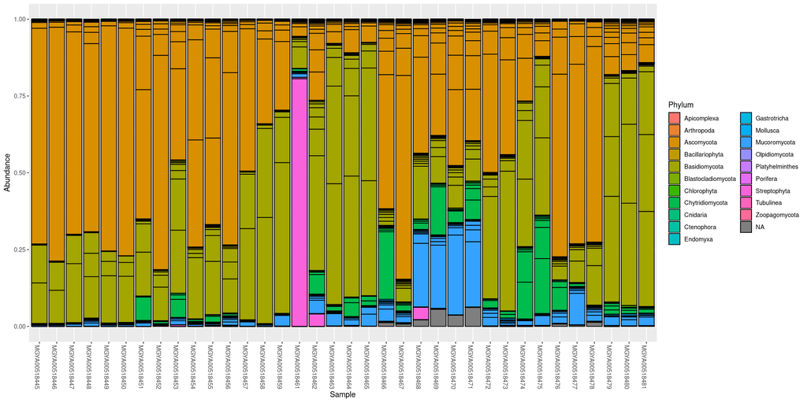

```r
# Transformations of abundances
psglom <- tax_glom(ps, "Order")
normed_ps <- transform_sample_counts(psglom, function(x) x/sum(x))
plot_bar(normed_ps, fill="Phylum")
```

```r
ord <- ordinate(ps, "NMDS", "bray")
```

```
Square root transformation
Wisconsin double standardization
*** Solution reached
```

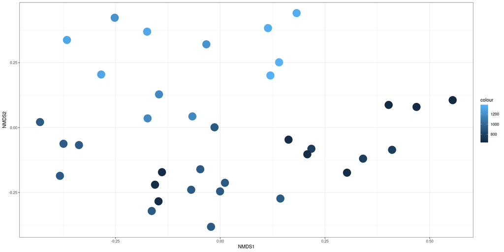

```r
plot_ordination(ps, ord) +
    geom_point(aes(color=as.numeric(sample_elevation)), size=8) +
    theme_bw()
```

## 5 - `mgnify_get_analyses_results`

- Retrieve functional results from API
- Taxonomy also available
  - not OTU based
- `mgnify_get_analyses_results(client, accessions, retrievelist)`
  - `retrievelist` : Which results do you want?
    - availability depends on pipeline and experiment type.
- Returns a list of functional result `data.frames`.

```r
acc_list <- metadata$analysis_accession[metadata$`analysis_experiment-type` == "assembly"]
func_results <- mgnify_get_analyses_results(mg, acc_list, retrievelist = c("go-slim", "taxonomy-ssu") )
```

```r
names(func_results)
```

1. 'go-slim'

2. 'taxonomy-ssu'

```r
func_results$`go-slim`
```

A data.frame: 116 × 19

| accession <chr> | description <chr> | lineage <chr> | MGYA00520940 <int> | MGYA00520966 <int> | MGYA00521001 <int> | MGYA00521025 <int> | MGYA00521063 <int> | MGYA00521064 <int> | MGYA00521126 <int> | MGYA00521127 <int> | MGYA00521190 <int> | MGYA00521191 <int> | MGYA00521216 <int> | MGYA00521217 <int> | MGYA00521258 <int> | MGYA00521259 <int> | MGYA00521311 <int> | MGYA00521312 <int> |
| --- | --- | --- | --- | --- | --- | --- | --- | --- | --- | --- | --- | --- | --- | --- | --- | --- | --- | --- |
| GO:0000015 | phosphopyruvate hydratase complex | cellular_component | 3 | 2 | 1 | 1 | 4 | 0 | 1 | 9 | 1 | 1 | 1 | 1 | 7 | 2 | 2 | 3 |
| GO:0000150 | recombinase activity | molecular_function | 7 | 0 | 2 | 3 | 13 | 9 | 5 | 7 | 0 | 14 | 14 | 5 | 16 | 14 | 16 | 11 |
| GO:0000160 | phosphorelay signal transduction system | biological_process | 79 | 3 | 34 | 0 | 11 | 1 | 59 | 57 | 3 | 92 | 4 | 9 | 65 | 65 | 62 | 85 |
| GO:0000166 | nucleotide binding | molecular_function | 718 | 171 | 272 | 160 | 708 | 104 | 477 | 1298 | 162 | 827 | 330 | 155 | 1137 | 822 | 821 | 993 |
| GO:0003674 | molecular function | molecular_function | 149 | 42 | 55 | 97 | 86 | 25 | 102 | 123 | 28 | 170 | 79 | 80 | 242 | 123 | 150 | 206 |
| GO:0003676 | nucleic acid binding | molecular_function | 760 | 164 | 302 | 227 | 763 | 217 | 528 | 1155 | 157 | 943 | 519 | 237 | 1099 | 889 | 1024 | 1000 |
| GO:0003700 | transcription factor activity, sequence-specific DNA binding | molecular_function | 163 | 4 | 76 | 19 | 38 | 9 | 135 | 114 | 7 | 219 | 20 | 25 | 192 | 153 | 132 | 217 |
| GO:0003735 | structural constituent of ribosome | molecular_function | 95 | 74 | 45 | 58 | 197 | 17 | 68 | 302 | 54 | 70 | 100 | 35 | 225 | 122 | 141 | 141 |
| GO:0003824 | catalytic activity | molecular_function | 583 | 52 | 220 | 60 | 348 | 37 | 335 | 580 | 49 | 649 | 144 | 71 | 640 | 589 | 544 | 702 |
| GO:0004601 | peroxidase activity | molecular_function | 16 | 0 | 2 | 5 | 4 | 0 | 6 | 7 | 0 | 16 | 0 | 0 | 9 | 8 | 12 | 17 |
| GO:0004803 | transposase activiy | molecular_function | 58 | 1 | 14 | 4 | 25 | 10 | 20 | 12 | 0 | 67 | 4 | 6 | 43 | 35 | 42 | 57 |
| GO:0004871 | signal transducer activity | molecular_function | 65 | 6 | 24 | 60 | 66 | 3 | 39 | 49 | 14 | 106 | 42 | 70 | 222 | 53 | 50 | 101 |
| GO:0004872 | receptor activity | molecular_function | 94 | 7 | 30 | 58 | 66 | 5 | 42 | 50 | 14 | 131 | 42 | 81 | 274 | 80 | 72 | 141 |
| GO:0005215 | transporter activity | molecular_function | 677 | 71 | 311 | 85 | 248 | 40 | 412 | 643 | 72 | 757 | 152 | 70 | 757 | 603 | 552 | 814 |
| GO:0005515 | protein binding | molecular_function | 161 | 22 | 50 | 147 | 97 | 17 | 112 | 170 | 22 | 156 | 103 | 139 | 497 | 154 | 138 | 187 |
| GO:0005575 | cellular component | cellular_component | 62 | 2 | 29 | 7 | 4 | 6 | 67 | 8 | 1 | 74 | 5 | 6 | 61 | 73 | 41 | 69 |
| GO:0005576 | extracellular region | cellular_component | 6 | 3 | 2 | 13 | 10 | 3 | 1 | 22 | 3 | 3 | 5 | 9 | 28 | 1 | 8 | 6 |
| GO:0005618 | cell wall | cellular_component | 5 | 0 | 2 | 0 | 3 | 3 | 4 | 14 | 0 | 7 | 1 | 0 | 3 | 5 | 7 | 4 |
| GO:0005622 | intracellular | cellular_component | 144 | 60 | 51 | 85 | 174 | 14 | 99 | 306 | 59 | 129 | 110 | 51 | 312 | 145 | 171 | 188 |
| GO:0005634 | nucleus | cellular_component | 2 | 1 | 0 | 20 | 10 | 0 | 0 | 4 | 0 | 2 | 6 | 24 | 69 | 1 | 2 | 4 |
| GO:0005694 | chromosome | cellular_component | 11 | 4 | 4 | 3 | 17 | 2 | 9 | 26 | 5 | 12 | 5 | 7 | 22 | 11 | 11 | 16 |
| GO:0005727 | extrachromosomal circular DNA | cellular_component | 3 | 1 | 1 | 1 | 8 | 3 | 3 | 7 | 0 | 5 | 3 | 1 | 2 | 8 | 5 | 10 |
| GO:0005737 | cytoplasm | cellular_component | 205 | 40 | 62 | 63 | 132 | 16 | 172 | 331 | 45 | 227 | 60 | 40 | 309 | 208 | 212 | 246 |
| GO:0005839 | proteasome core complex | cellular_component | 5 | 0 | 1 | 8 | 0 | 0 | 1 | 6 | 0 | 3 | 2 | 1 | 11 | 2 | 1 | 5 |
| GO:0005840 | ribosome | cellular_component | 94 | 74 | 44 | 58 | 197 | 17 | 69 | 300 | 53 | 70 | 100 | 34 | 226 | 124 | 142 | 141 |
| GO:0005874 | microtubule | cellular_component | 2 | 2 | 0 | 4 | 3 | 2 | 0 | 3 | 1 | 0 | 4 | 2 | 8 | 1 | 3 | 4 |
| GO:0005886 | plasma membrane | cellular_component | 65 | 2 | 31 | 22 | 34 | 6 | 38 | 62 | 7 | 70 | 19 | 24 | 91 | 50 | 46 | 86 |
| GO:0005975 | carbohydrate metabolic process | biological_process | 311 | 33 | 155 | 41 | 198 | 20 | 184 | 401 | 34 | 354 | 41 | 30 | 350 | 294 | 295 | 351 |
| GO:0006091 | generation of precursor metabolites and energy | biological_process | 94 | 15 | 37 | 19 | 54 | 10 | 58 | 73 | 10 | 95 | 24 | 16 | 123 | 69 | 70 | 112 |
| GO:0006259 | DNA metabolic process | biological_process | 328 | 75 | 129 | 59 | 378 | 126 | 203 | 462 | 59 | 422 | 266 | 88 | 391 | 435 | 468 | 429 |
| ⋮ | ⋮ | ⋮ | ⋮ | ⋮ | ⋮ | ⋮ | ⋮ | ⋮ | ⋮ | ⋮ | ⋮ | ⋮ | ⋮ | ⋮ | ⋮ | ⋮ | ⋮ | ⋮ |
| GO:0019222 | regulation of metabolic process | biological_process | 371 | 14 | 162 | 51 | 119 | 29 | 306 | 310 | 21 | 484 | 63 | 62 | 409 | 350 | 333 | 460 |
| GO:0019842 | vitamin binding | molecular_function | 30 | 3 | 14 | 2 | 15 | 1 | 14 | 27 | 3 | 31 | 10 | 3 | 30 | 28 | 34 | 30 |
| GO:0019867 | outer membrane | cellular_component | 73 | 2 | 16 | 6 | 10 | 7 | 51 | 9 | 1 | 86 | 8 | 6 | 65 | 77 | 73 | 87 |
| GO:0019898 | extrinsic component of membrane | cellular_component | 0 | 0 | 0 | 1 | 0 | 0 | 0 | 0 | 0 | 0 | 1 | 2 | 2 | 0 | 0 | 0 |
| GO:0030170 | pyridoxal phosphate binding | molecular_function | 70 | 2 | 27 | 6 | 26 | 2 | 40 | 63 | 1 | 72 | 12 | 4 | 70 | 60 | 59 | 86 |
| GO:0030246 | carbohydrate binding | molecular_function | 32 | 2 | 8 | 4 | 10 | 1 | 17 | 36 | 0 | 35 | 4 | 6 | 36 | 28 | 24 | 24 |
| GO:0031224 | intrinsic to membrane | cellular_component | 607 | 38 | 249 | 153 | 261 | 32 | 389 | 570 | 45 | 695 | 158 | 141 | 827 | 525 | 496 | 707 |
| GO:0033202 | DNA helicase complex | cellular_component | 1 | 0 | 0 | 0 | 0 | 0 | 1 | 4 | 1 | 1 | 2 | 1 | 1 | 3 | 2 | 2 |
| GO:0042221 | response to chemical | biological_process | 48 | 5 | 31 | 10 | 12 | 1 | 41 | 18 | 3 | 62 | 6 | 2 | 60 | 43 | 29 | 78 |
| GO:0042575 | DNA polymerase complex | cellular_component | 7 | 0 | 2 | 1 | 4 | 0 | 4 | 11 | 1 | 3 | 0 | 0 | 5 | 4 | 6 | 7 |
| GO:0042597 | periplasmic space | cellular_component | 64 | 0 | 23 | 3 | 2 | 3 | 51 | 11 | 0 | 75 | 1 | 4 | 45 | 62 | 40 | 99 |
| GO:0043167 | ion binding | molecular_function | 676 | 162 | 259 | 157 | 681 | 100 | 432 | 1230 | 154 | 763 | 327 | 157 | 1088 | 755 | 772 | 917 |
| GO:0043190 | ATP-binding cassette (ABC) transporter complex | cellular_component | 23 | 1 | 10 | 0 | 2 | 0 | 15 | 16 | 0 | 27 | 2 | 0 | 25 | 21 | 14 | 28 |
| GO:0043934 | sporulation | biological_process | 0 | 0 | 0 | 0 | 4 | 1 | 0 | 1 | 0 | 0 | 4 | 0 | 0 | 1 | 2 | 0 |
| GO:0044281 | small molecule metabolic process | biological_process | 649 | 87 | 233 | 79 | 455 | 48 | 466 | 933 | 106 | 713 | 181 | 68 | 766 | 642 | 627 | 781 |
| GO:0045454 | cell redox homeostasis | biological_process | 23 | 5 | 16 | 8 | 14 | 7 | 19 | 37 | 5 | 34 | 14 | 2 | 30 | 24 | 29 | 32 |
| GO:0046718 | viral entry into host cell | biological_process | 0 | 0 | 0 | 0 | 0 | 0 | 0 | 0 | 0 | 0 | 1 | 0 | 1 | 0 | 1 | 1 |
| GO:0046872 | metal ion binding | molecular_function | 324 | 44 | 111 | 82 | 171 | 31 | 228 | 324 | 42 | 339 | 120 | 73 | 459 | 287 | 299 | 364 |
| GO:0046906 | tetrapyrrole binding | molecular_function | 41 | 2 | 11 | 4 | 15 | 1 | 22 | 11 | 0 | 45 | 9 | 15 | 69 | 31 | 32 | 44 |
| GO:0048500 | signal recognition particle | cellular_component | 3 | 2 | 0 | 1 | 2 | 0 | 1 | 4 | 0 | 0 | 1 | 1 | 4 | 4 | 3 | 1 |
| GO:0050662 | coenzyme binding | molecular_function | 155 | 16 | 66 | 18 | 71 | 9 | 119 | 150 | 17 | 188 | 37 | 19 | 182 | 170 | 156 | 221 |
| GO:0051536 | iron-sulfur cluster binding | molecular_function | 83 | 7 | 25 | 6 | 38 | 5 | 81 | 44 | 9 | 102 | 13 | 6 | 90 | 90 | 60 | 102 |
| GO:0065003 | macromolecular complex assembly | biological_process | 14 | 2 | 2 | 9 | 3 | 0 | 9 | 19 | 0 | 13 | 10 | 3 | 32 | 11 | 11 | 16 |
| GO:0071103 | DNA conformation change | biological_process | 32 | 14 | 16 | 3 | 80 | 17 | 22 | 68 | 7 | 46 | 34 | 4 | 41 | 43 | 56 | 50 |
| GO:0071840 | cellular component organization or biogenesis | biological_process | 96 | 12 | 51 | 12 | 57 | 10 | 85 | 126 | 15 | 125 | 34 | 14 | 126 | 117 | 92 | 134 |
| GO:0071973 | bacterial-type flagellar cell motility | biological_process | 43 | 0 | 22 | 0 | 3 | 1 | 34 | 5 | 0 | 37 | 5 | 0 | 34 | 24 | 21 | 53 |
| GO:0090484 | drug transporter activity | molecular_function | 10 | 2 | 3 | 0 | 8 | 1 | 9 | 11 | 3 | 15 | 3 | 0 | 11 | 9 | 7 | 16 |
| GO:0098796 | membrane protein complex | cellular_component | 11 | 0 | 1 | 11 | 1 | 1 | 2 | 6 | 1 | 8 | 6 | 8 | 29 | 3 | 8 | 6 |
| GO:1902494 | catalytic complex | cellular_component | 10 | 2 | 2 | 6 | 8 | 2 | 11 | 18 | 2 | 13 | 9 | 8 | 41 | 10 | 14 | 16 |
| GO:1990204 | oxidoreductase complex | cellular_component | 24 | 2 | 7 | 4 | 3 | 0 | 21 | 17 | 2 | 20 | 4 | 1 | 23 | 28 | 18 | 29 |

```r
func_results$`taxonomy-ssu`
```

A data.frame: 72 × 24

| order <chr> | super.kingdom <chr> | class <chr> | family <chr> | kingdom <chr> | phylum <chr> | genus <chr> | species <chr> | MGYA00520940 <int> | MGYA00520966 <int> | ⋯ | MGYA00521126 <int> | MGYA00521127 <int> | MGYA00521190 <int> | MGYA00521191 <int> | MGYA00521216 <int> | MGYA00521217 <int> | MGYA00521258 <int> | MGYA00521259 <int> | MGYA00521311 <int> | MGYA00521312 <int> |
| --- | --- | --- | --- | --- | --- | --- | --- | --- | --- | --- | --- | --- | --- | --- | --- | --- | --- | --- | --- | --- |
|  | Chloroplast |  |  |  |  |  | Solanum_commersonii_(Commerson's_wild_potato) | 0 | 1 | ⋯ | 0 | 0 | 0 | 0 | 0 | 0 | 0 | 0 | 0 | 0 |
| Bacillales | Bacteria | Bacilli | Paenibacillaceae |  | Firmicutes | Paenibacillus | NA | 0 | 0 | ⋯ | 0 | 0 | 0 | 0 | 1 | 0 | 0 | 0 | 0 | 0 |
| Bacillales | Bacteria | Bacilli | Staphylococcaceae |  | Firmicutes | Staphylococcus | NA | 0 | 0 | ⋯ | 0 | 0 | 0 | 0 | 0 | 0 | 0 | 0 | 0 | 0 |
| Bacteroidales | Bacteria | Bacteroidia | Bacteroidaceae |  | Bacteroidetes | Bacteroides | NA | 0 | 0 | ⋯ | 0 | 0 | 0 | 0 | 0 | 0 | 1 | 0 | 0 | 0 |
| Bacteroidales | Bacteria | Bacteroidia | Dysgonamonadaceae |  | Bacteroidetes | NA | NA | 0 | 0 | ⋯ | 0 | 0 | 0 | 0 | 0 | 0 | 0 | 1 | 0 | 0 |
| Bacteroidales | Bacteria | Bacteroidia | Prevotellaceae |  | Bacteroidetes | NA | NA | 0 | 0 | ⋯ | 0 | 0 | 0 | 1 | 0 | 0 | 0 | 0 | 0 | 0 |
| Bifidobacteriales | Bacteria | Actinobacteria | Bifidobacteriaceae |  | Actinobacteria | NA | NA | 0 | 0 | ⋯ | 0 | 0 | 0 | 0 | 0 | 0 | 0 | 0 | 0 | 1 |
| Burkholderiales | Bacteria | Betaproteobacteria | Alcaligenaceae |  | Proteobacteria | NA | NA | 0 | 0 | ⋯ | 0 | 0 | 0 | 0 | 0 | 0 | 0 | 0 | 0 | 0 |
| Burkholderiales | Bacteria | Betaproteobacteria | Burkholderiaceae |  | Proteobacteria | Lautropia | Lautropia_mirabilis | 0 | 0 | ⋯ | 0 | 0 | 0 | 0 | 0 | 0 | 0 | 0 | 0 | 0 |
| Burkholderiales | Bacteria | Betaproteobacteria | Burkholderiaceae |  | Proteobacteria | Ralstonia | NA | 0 | 0 | ⋯ | 0 | 0 | 0 | 0 | 0 | 0 | 1 | 0 | 1 | 0 |
| Burkholderiales | Bacteria | Betaproteobacteria | Comamonadaceae |  | Proteobacteria | NA | NA | 1 | 0 | ⋯ | 0 | 0 | 0 | 1 | 0 | 0 | 0 | 0 | 0 | 1 |
| Burkholderiales | Bacteria | Betaproteobacteria | NA |  | Proteobacteria | NA | NA | 0 | 0 | ⋯ | 0 | 1 | 0 | 0 | 0 | 1 | 1 | 0 | 0 | 0 |
| Campylobacterales | Bacteria | Epsilonproteobacteria | Campylobacteraceae |  | Proteobacteria | NA | NA | 0 | 0 | ⋯ | 0 | 0 | 0 | 0 | 0 | 0 | 0 | 0 | 0 | 0 |
| Campylobacterales | Bacteria | Epsilonproteobacteria | Helicobacteraceae |  | Proteobacteria | NA | NA | 0 | 0 | ⋯ | 0 | 0 | 0 | 0 | 0 | 0 | 0 | 1 | 0 | 0 |
| Chlamydiales | Bacteria | Chlamydiia | Candidatus_Clavichlamydiaceae |  | Chlamydiae | NA | NA | 0 | 0 | ⋯ | 0 | 0 | 0 | 0 | 0 | 0 | 0 | 0 | 0 | 0 |
| Chlamydiales | Bacteria | Chlamydiia | Chlamydiaceae |  | Chlamydiae | NA | NA | 0 | 2 | ⋯ | 0 | 0 | 0 | 0 | 0 | 0 | 0 | 0 | 0 | 2 |
| Clostridiales | Bacteria | Clostridia | Clostridiaceae |  | Firmicutes | Clostridium | NA | 0 | 0 | ⋯ | 1 | 0 | 0 | 0 | 1 | 0 | 0 | 0 | 0 | 0 |
| Clostridiales | Bacteria | Clostridia | Lachnospiraceae |  | Firmicutes | Blautia | NA | 0 | 0 | ⋯ | 0 | 0 | 0 | 0 | 0 | 0 | 0 | 0 | 0 | 1 |
| Clostridiales | Bacteria | Clostridia | Lachnospiraceae |  | Firmicutes | NA | NA | 0 | 1 | ⋯ | 0 | 1 | 0 | 0 | 0 | 0 | 0 | 0 | 1 | 0 |
| Clostridiales | Bacteria | Clostridia | NA |  | Firmicutes | NA | NA | 0 | 0 | ⋯ | 0 | 1 | 0 | 0 | 1 | 0 | 0 | 1 | 3 | 1 |
| Coriobacteriales | Bacteria | Coriobacteriia | Coriobacteriaceae |  | Actinobacteria | Collinsella | NA | 0 | 0 | ⋯ | 0 | 0 | 0 | 0 | 0 | 0 | 0 | 0 | 0 | 1 |
| Cyclophyllidea | Eukaryota | Cestoda | Hymenolepididae | Metazoa | Platyhelminthes | Hymenolepis | NA | 0 | 0 | ⋯ | 0 | 0 | 0 | 0 | 0 | 0 | 0 | 0 | 0 | 0 |
| Cyrtophorida | Eukaryota | Phyllopharyngea | NA |  |  | NA | NA | 0 | 1 | ⋯ | 0 | 0 | 0 | 0 | 0 | 0 | 0 | 0 | 0 | 0 |
| Enterobacterales | Bacteria | Gammaproteobacteria | Enterobacteriaceae |  | Proteobacteria | NA | NA | 0 | 0 | ⋯ | 0 | 0 | 0 | 1 | 1 | 0 | 0 | 1 | 1 | 0 |
| Enterobacterales | Bacteria | Gammaproteobacteria | Yersiniaceae |  | Proteobacteria | Serratia | Serratia_sp._Ag1 | 0 | 0 | ⋯ | 0 | 0 | 0 | 0 | 0 | 0 | 0 | 0 | 1 | 0 |
| Enterobacterales | Bacteria | Gammaproteobacteria | NA |  | Proteobacteria | NA | NA | 0 | 0 | ⋯ | 0 | 0 | 0 | 0 | 1 | 0 | 0 | 0 | 0 | 0 |
| Eucoccidiorida | Eukaryota | Coccidia | Cryptosporidiidae |  | Apicomplexa | NA | NA | 0 | 0 | ⋯ | 0 | 0 | 0 | 0 | 0 | 0 | 1 | 0 | 0 | 0 |
| Eurotiales | Eukaryota | Eurotiomycetes | NA | Fungi | Ascomycota | NA | NA | 0 | 0 | ⋯ | 0 | 0 | 0 | 0 | 1 | 0 | 0 | 0 | 0 | 0 |
| Flavobacteriales | Bacteria | Flavobacteriia | Flavobacteriaceae |  | Bacteroidetes | Bergeyella | NA | 0 | 0 | ⋯ | 0 | 0 | 0 | 0 | 1 | 0 | 0 | 0 | 0 | 0 |
| Flavobacteriales | Bacteria | Flavobacteriia | Flavobacteriaceae |  | Bacteroidetes | Chryseobacterium | NA | 0 | 0 | ⋯ | 0 | 0 | 0 | 0 | 0 | 0 | 1 | 0 | 0 | 0 |
| ⋮ | ⋮ | ⋮ | ⋮ | ⋮ | ⋮ | ⋮ | ⋮ | ⋮ | ⋮ | ⋱ | ⋮ | ⋮ | ⋮ | ⋮ | ⋮ | ⋮ | ⋮ | ⋮ | ⋮ | ⋮ |
| Mycoplasmatales | Bacteria | Mollicutes | NA |  | Tenericutes | NA | NA | 0 | 0 | ⋯ | 0 | 0 | 0 | 0 | 0 | 0 | 0 | 0 | 0 | 1 |
| Neisseriales | Bacteria | Betaproteobacteria | Neisseriaceae |  | Proteobacteria | Kingella | NA | 1 | 0 | ⋯ | 0 | 0 | 0 | 0 | 0 | 0 | 0 | 0 | 0 | 0 |
| Neisseriales | Bacteria | Betaproteobacteria | Neisseriaceae |  | Proteobacteria | NA | NA | 0 | 0 | ⋯ | 0 | 0 | 0 | 0 | 1 | 0 | 0 | 0 | 0 | 0 |
| Nostocales | Bacteria |  | NA |  | Cyanobacteria | NA | NA | 0 | 0 | ⋯ | 0 | 0 | 0 | 0 | 1 | 0 | 0 | 0 | 0 | 0 |
| Oligoflexales | Bacteria | Oligoflexia | NA |  | Proteobacteria | NA | NA | 0 | 0 | ⋯ | 0 | 0 | 0 | 0 | 0 | 1 | 0 | 0 | 0 | 0 |
| Propionibacteriales | Bacteria | Actinobacteria | Propionibacteriaceae |  | Actinobacteria | NA | NA | 0 | 0 | ⋯ | 0 | 1 | 0 | 0 | 0 | 0 | 0 | 0 | 0 | 0 |
| Pseudomonadales | Bacteria | Gammaproteobacteria | Moraxellaceae |  | Proteobacteria | Acinetobacter | NA | 1 | 0 | ⋯ | 0 | 0 | 0 | 0 | 0 | 0 | 0 | 0 | 0 | 0 |
| Rhodobacterales | Bacteria | Alphaproteobacteria | Rhodobacteraceae |  | Proteobacteria | NA | NA | 2 | 0 | ⋯ | 0 | 0 | 0 | 1 | 0 | 0 | 0 | 0 | 0 | 2 |
| Rhodospirillales | Bacteria | Alphaproteobacteria | Acetobacteraceae |  | Proteobacteria | Acetobacter | NA | 0 | 0 | ⋯ | 0 | 0 | 0 | 0 | 0 | 0 | 1 | 0 | 0 | 0 |
| Rhodospirillales | Bacteria | Alphaproteobacteria | Acetobacteraceae |  | Proteobacteria | NA | NA | 0 | 0 | ⋯ | 0 | 0 | 0 | 0 | 1 | 0 | 1 | 0 | 0 | 0 |
| Sphingobacteriales | Bacteria | Sphingobacteriia | Sphingobacteriaceae |  | Bacteroidetes | Sphingobacterium | Sphingobacterium_sp._CFCC_11742 | 0 | 0 | ⋯ | 0 | 0 | 0 | 0 | 0 | 0 | 0 | 0 | 0 | 0 |
| Sphingobacteriales | Bacteria | Sphingobacteriia | Sphingobacteriaceae |  | Bacteroidetes | Sphingobacterium | NA | 0 | 0 | ⋯ | 0 | 0 | 0 | 0 | 0 | 0 | 0 | 1 | 0 | 0 |
| Sphingobacteriales | Bacteria | Sphingobacteriia | Sphingobacteriaceae |  | Bacteroidetes | NA | NA | 0 | 0 | ⋯ | 0 | 0 | 0 | 0 | 0 | 0 | 0 | 1 | 1 | 0 |
| Sphingomonadales | Bacteria | Alphaproteobacteria | Sphingomonadaceae |  | Proteobacteria | NA | NA | 0 | 0 | ⋯ | 0 | 0 | 0 | 0 | 1 | 0 | 0 | 0 | 0 | 0 |
| Sphingomonadales | Bacteria | Alphaproteobacteria | NA |  | Proteobacteria | NA | NA | 0 | 0 | ⋯ | 0 | 0 | 0 | 0 | 0 | 0 | 0 | 0 | 0 | 0 |
| Spirochaetales | Bacteria | Spirochaetia | Spirochaetaceae |  | Spirochaetes | NA | NA | 0 | 0 | ⋯ | 0 | 2 | 0 | 0 | 0 | 0 | 0 | 0 | 0 | 0 |
| Veillonellales | Bacteria | Negativicutes | Veillonellaceae |  | Firmicutes | Veillonella | NA | 0 | 0 | ⋯ | 0 | 0 | 0 | 0 | 1 | 0 | 0 | 0 | 1 | 0 |
| Xanthomonadales | Bacteria | Gammaproteobacteria | Xanthomonadaceae |  | Proteobacteria | Stenotrophomonas | NA | 0 | 1 | ⋯ | 0 | 0 | 0 | 0 | 0 | 0 | 0 | 0 | 0 | 0 |
| NA | Bacteria | Actinobacteria | NA |  | Actinobacteria | NA | NA | 0 | 0 | ⋯ | 0 | 0 | 0 | 0 | 0 | 0 | 0 | 0 | 0 | 0 |
| NA | Bacteria | Betaproteobacteria | NA |  | Proteobacteria | NA | NA | 1 | 0 | ⋯ | 0 | 0 | 0 | 0 | 0 | 0 | 0 | 0 | 0 | 0 |
| NA | Bacteria | Gammaproteobacteria | NA |  | Proteobacteria | NA | NA | 1 | 1 | ⋯ | 0 | 0 | 0 | 0 | 0 | 0 | 1 | 1 | 1 | 0 |
| NA | Bacteria | NA | NA |  | Firmicutes | NA | NA | 0 | 0 | ⋯ | 0 | 1 | 0 | 1 | 0 | 0 | 0 | 0 | 0 | 0 |
| NA | Bacteria | NA | NA |  | Proteobacteria | NA | NA | 0 | 0 | ⋯ | 0 | 0 | 0 | 0 | 0 | 0 | 1 | 0 | 0 | 0 |
| NA | Bacteria | NA | NA | NA | NA | NA | NA | 0 | 1 | ⋯ | 0 | 0 | 1 | 0 | 1 | 0 | 1 | 2 | 0 | 0 |
| NA | Chloroplast | NA | NA | NA | NA | NA | NA | 0 | 1 | ⋯ | 0 | 0 | 0 | 0 | 0 | 0 | 3 | 0 | 0 | 0 |
| NA | Eukaryota | Mammalia | NA | Metazoa | Chordata | NA | NA | 0 | 0 | ⋯ | 0 | 0 | 0 | 1 | 0 | 0 | 1 | 1 | 0 | 0 |
| NA | Eukaryota | NA | NA | Metazoa | NA | NA | NA | 0 | 2 | ⋯ | 1 | 0 | 1 | 0 | 1 | 1 | 0 | 0 | 1 | 0 |
| NA | Eukaryota | NA | NA | Viridiplantae | Streptophyta | NA | NA | 0 | 0 | ⋯ | 0 | 1 | 0 | 0 | 1 | 0 | 2 | 1 | 0 | 1 |
| NA | Eukaryota | NA | NA | NA | NA | NA | NA | 0 | 1 | ⋯ | 0 | 0 | 1 | 1 | 0 | 0 | 1 | 0 | 0 | 0 |
| NA | Mitochondria | NA | NA | NA | NA | NA | NA | 0 | 0 | ⋯ | 0 | 0 | 0 | 0 | 0 | 1 | 0 | 0 | 0 | 2 |

- Can be **slow** - especially for Interpro.
- Extra option - `bulk_dl`
  - Flag to retrieve per-study results
  - not always reliable
  - **Extremely** fast when it works
    - so try it - warnings will be issued

```r
#This still using the local cache, but on a per-analysis basis
tmp <- mgnify_get_analyses_results(mg, acc_list, retrievelist = c("interpro-identifiers") )
```

```r
tmp2 <- mgnify_get_analyses_results(mg, acc_list, retrievelist = c("interpro-identifiers"), bulk_dl=T )
```

```r
head(tmp$`interpro-identifiers` == tmp2$`interpro-identifiers`)
```

A matrix: 6 × 18 of type lgl

| accession | description | MGYA00520940 | MGYA00520966 | MGYA00521001 | MGYA00521025 | MGYA00521063 | MGYA00521064 | MGYA00521126 | MGYA00521127 | MGYA00521190 | MGYA00521191 | MGYA00521216 | MGYA00521217 | MGYA00521258 | MGYA00521259 | MGYA00521311 | MGYA00521312 |
| --- | --- | --- | --- | --- | --- | --- | --- | --- | --- | --- | --- | --- | --- | --- | --- | --- | --- |
| TRUE | TRUE | TRUE | TRUE | TRUE | TRUE | TRUE | TRUE | TRUE | TRUE | TRUE | TRUE | TRUE | TRUE | TRUE | TRUE | TRUE | TRUE |
| TRUE | TRUE | TRUE | TRUE | TRUE | TRUE | TRUE | TRUE | TRUE | TRUE | TRUE | TRUE | TRUE | TRUE | TRUE | TRUE | TRUE | TRUE |
| TRUE | TRUE | TRUE | TRUE | TRUE | TRUE | TRUE | TRUE | TRUE | TRUE | TRUE | TRUE | TRUE | TRUE | TRUE | TRUE | TRUE | TRUE |
| TRUE | TRUE | TRUE | TRUE | TRUE | TRUE | TRUE | TRUE | TRUE | TRUE | TRUE | TRUE | TRUE | TRUE | TRUE | TRUE | TRUE | TRUE |
| TRUE | TRUE | TRUE | TRUE | TRUE | TRUE | TRUE | TRUE | TRUE | TRUE | TRUE | TRUE | TRUE | TRUE | TRUE | TRUE | TRUE | TRUE |
| TRUE | TRUE | TRUE | TRUE | TRUE | TRUE | TRUE | TRUE | TRUE | TRUE | TRUE | TRUE | TRUE | TRUE | TRUE | TRUE | TRUE | TRUE |

# 6 - `mgnify_download` - get raw results files.

- Intended for retrieval of larger TSV and FASTA files
- multistep process:
  - `mgnify_get_download_urls` - what's available
  - `mgnify_download` - Actually retrieve the file
- `mgnify_get_download_urls(client, accessions, accession_type)`
  - `accession_type` - `assemblies`, `analyses`, `studies` etc
  - Returns `data.frame` -includes file type, format and location URL `download_url` is what you want.

```r
dl_df <- mgnify_get_download_urls(mg, acc_list, "analyses")
head(dl_df)
```

A data.frame: 6 × 17

| type <chr> | id <chr> | attributes.alias <chr> | attributes.file.format.name <chr> | attributes.file.format.extension <chr> | attributes.file.format.compression <lgl> | attributes.description.label <chr> | attributes.description.description <chr> | attributes.group.type <chr> | attributes.file.checksum.checksum <chr> | attributes.file.checksum.checksum.algorithm <chr> | relationships.pipeline.data.type <chr> | relationships.pipeline.data.id <chr> | relationships.pipeline.related <chr> | download_url <chr> | accession <chr> | accession_type <chr> |
| --- | --- | --- | --- | --- | --- | --- | --- | --- | --- | --- | --- | --- | --- | --- | --- | --- |
| analysis-job-downloads | ERZ809583_FASTA.fasta.gz | ERZ809583_FASTA.fasta.gz | FASTA | fasta | TRUE | Processed contigs | Processed contigs | Sequence data |  |  | pipelines | 4.1 | https://www.ebi.ac.uk/metagenomics/api/v1/pipelines/4.1?format=json | https://www.ebi.ac.uk/metagenomics/api/v1/analyses/MGYA00520940/file/ERZ809583_FASTA.fasta.gz | MGYA00520940 | analyses |
| analysis-job-downloads | ERZ809583_FASTA_CDS_annotated.faa.gz | ERZ809583_FASTA_CDS_annotated.faa.gz | FASTA | fasta | TRUE | Predicted CDS with annotation | Predicted coding sequences with InterPro match (FASTA) | Sequence data |  |  | pipelines | 4.1 | https://www.ebi.ac.uk/metagenomics/api/v1/pipelines/4.1?format=json | https://www.ebi.ac.uk/metagenomics/api/v1/analyses/MGYA00520940/file/ERZ809583_FASTA_CDS_annotated.faa.gz | MGYA00520940 | analyses |
| analysis-job-downloads | ERZ809583_FASTA_CDS_unannotated.faa.gz | ERZ809583_FASTA_CDS_unannotated.faa.gz | FASTA | fasta | TRUE | Predicted CDS without annotation | Predicted CDS without annotation | Sequence data |  |  | pipelines | 4.1 | https://www.ebi.ac.uk/metagenomics/api/v1/pipelines/4.1?format=json | https://www.ebi.ac.uk/metagenomics/api/v1/analyses/MGYA00520940/file/ERZ809583_FASTA_CDS_unannotated.faa.gz | MGYA00520940 | analyses |
| analysis-job-downloads | ERZ809583_FASTA_contigsWithpCDS.fasta.gz | ERZ809583_FASTA_contigsWithpCDS.fasta.gz | FASTA | fasta | TRUE | Processed contigs with pCDS | All contigs that have predicted CDS | Sequence data |  |  | pipelines | 4.1 | https://www.ebi.ac.uk/metagenomics/api/v1/pipelines/4.1?format=json | https://www.ebi.ac.uk/metagenomics/api/v1/analyses/MGYA00520940/file/ERZ809583_FASTA_contigsWithpCDS.fasta.gz | MGYA00520940 | analyses |
| analysis-job-downloads | ERZ809583_FASTA_interproscan.fasta.gz | ERZ809583_FASTA_interproscan.fasta.gz | FASTA | fasta | TRUE | Processed contigs with annotation | All contigs with an interproscan match | Sequence data |  |  | pipelines | 4.1 | https://www.ebi.ac.uk/metagenomics/api/v1/pipelines/4.1?format=json | https://www.ebi.ac.uk/metagenomics/api/v1/analyses/MGYA00520940/file/ERZ809583_FASTA_interproscan.fasta.gz | MGYA00520940 | analyses |
| analysis-job-downloads | ERZ809583_FASTA_noFunction.fasta.gz | ERZ809583_FASTA_noFunction.fasta.gz | FASTA | fasta | TRUE | Processed contigs without annotation | All contigs with a predicted CDS but no interproscan match | Sequence data |  |  | pipelines | 4.1 | https://www.ebi.ac.uk/metagenomics/api/v1/pipelines/4.1?format=json | https://www.ebi.ac.uk/metagenomics/api/v1/analyses/MGYA00520940/file/ERZ809583_FASTA_noFunction.fasta.gz | MGYA00520940 | analyses |

- `mgnify_download(client, url, target_filename, readfunc)`
  - `target_filename` - where to store the downloaded file. Default to cache folder
  - `readfunc` - function to process file "inline".
- Returns downloaded file location
  - in cache or `target_filename`

```r
#Choosing a single file
analysis_subset = dl_df$accession == "MGYA00520940"
ftype_subset = dl_df$attributes.description.label == "Predicted ORF with annotation"


file_url = dl_df$download_url[analysis_subset & ftype_subset]

file_url
```

'https://www.ebi.ac.uk/metagenomics/api/v1/analyses/MGYA00520940/file/ERZ809583_FASTA_ORF_annotated.ffn.gz'

```r
mgnify_download(mg, file_url)
```

'~/MyLocalMGnifyCache/analyses/MGYA00520940/file/ERZ809583_FASTA_ORF_annotated.ffn.gz'

```r
(file_location <- mgnify_download(mg, file_url, target_filename = "~/Metagenomics/Proteins.fasta"))
```

'~/Metagenomics/Proteins.fasta'

```r
library(Biostrings)
readAAStringSet(file_location)
```

```
  A AAStringSet instance of length 9746
       width seq                                            names
   [1]   885 ATGTTTACTAAAGCATTGAAAT...GAAATGGTTGACAGCAAATAA ERZ809583.1-NODE-...
   [2]   729 GTGATTAAAGATTTCTTTAAAG...ATTAAATCTATCGTTGGATAA ERZ809583.1-NODE-...
   [3]  1311 TTGAAACAGATTAAAACAACAT...ACTTGGGAACCATTAGAATAA ERZ809583.1-NODE-...
   [4]   594 ATGAATATTAACTTAAATGTTA...GATACTACTGGTGAAATGTAA ERZ809583.1-NODE-...
   [5]   252 ATGGCAGGATATCATTTAGATG...GAAGGTGGATATAGAAAATGA ERZ809583.1-NODE-...
   ...   ... ...
[9742]   507 CCAGGAGTGAACAACCAGCCCT...ACACCGCCGCCTCCTTACACC ERZ809583.7829-NO...
[9743]   135 GAAGAAGTGAACGTCATTACCT...ATGGGTACCCGTAGCGGTGAT ERZ809583.7830-NO...
[9744]   501 GTTGGGTGTGTTTGGGCGGCGG...CCCTTCACCAAACACACCCAA ERZ809583.7930-NO...
[9745]   249 TTGGTGATGGGCGCAACCTTCC...AGTCTTGAACACAGCGTCGGA ERZ809583.8020-NO...
[9746]   288 ACCGCTACCGGCGATGGTCTGT...ATACTGGCCTTGCAGGACAAA ERZ809583.8193-NO...
```

# Wrapping up

- Don't worry if you didn't follow it all.
  - Read the vignette
- *Please* give feedback - `ben.allen@ncl.ac.uk`
  - Current structure biased to what I think is needed.
- Have a go at the exercises
  - but there's a lot to do...

It's a lot to take in at once And clearly requires reasonable R abilities.